# Netflix

G1401211094 Hanifa Rahmacindia Nasution

2023-10-30

# Library

```r
library(rio)
library(ggplot2)
library(tsibble)
library(tseries)
library(MASS)
library(forecast)
library(TSA)
library(TTR)
library(aTSA)
library(graphics)
```

# Data Preparation

## Import Data

```r
raw.data <- import("https://raw.githubusercontent.com/HanifaNasution/Praktikum-MPDW/main/Data/NFLX.csv")
```

## Data Checking

Cek Tipe data.

```r
str(raw.data)
```

```
## 'data.frame':    1258 obs. of  8 variables:
##  $ Name     : chr  "NFLX" "NFLX" "NFLX" "NFLX" ...
##  $ Date     : chr  "7/30/18" "7/31/18" "8/1/18" "8/2/18" ...
##  $ Open     : num  352 332 336 337 348 ...
##  $ High     : num  352 342 344 345 348 ...
##  $ Low      : num  334 328 334 335 338 ...
##  $ Close    : num  335 337 338 344 343 ...
##  $ Adj Close: num  335 337 338 344 343 ...
##  $ Volume   : int  18260700 14085400 7790500 7131300 8848400 8198100 7970900 5394700 4820300 4328400 ...
```

Tanggal masih berupa data Karakter, harus diubah.

Cek Data kosong.

```r
sum(is.na(raw.data))
```

```
## [1] 0
```

Tidak ada data kosong.

## Penyesuaian Tipe Data

```r
library(dplyr)
data <- raw.data %>%
  mutate(
    Date = as.Date(raw.data[, 2], format = "%m/%d/%y"), #Mengubah menjadi Date
    across(3:ncol(raw.data), as.numeric)                #Mengubah menjadi Numerik
  )
str(data)
```

```
## 'data.frame':    1258 obs. of  8 variables:
##  $ Name     : chr  "NFLX" "NFLX" "NFLX" "NFLX" ...
##  $ Date     : Date, format: "2018-07-30" "2018-07-31" ...
##  $ Open     : num  352 332 336 337 348 ...
##  $ High     : num  352 342 344 345 348 ...
##  $ Low      : num  334 328 334 335 338 ...
##  $ Close    : num  335 337 338 344 343 ...
##  $ Adj Close: num  335 337 338 344 343 ...
##  $ Volume   : num  18260700 14085400 7790500 7131300 8848400 ...
```

## Rechecking Data

Cek kembali data kosong.

```r
cat('Banyaknya Data Kosong', sum(is.na(data)))
```

```
## Banyaknya Data Kosong 0
```

Sudah tidak ada data kosong

## Cek Periode Data

```r
library(lubridate)
dates <- as.Date(data$Date)

# Buat rentang waktu mulai dari tanggal pertama hingga tanggal terakhir dalam data
complete_dates <- seq(as.Date("2018-07-30"), as.Date("2023-07-28"), by = "days")
complete_ts_data <- ts(NA, start = c(2023,07,30), frequency = 1)

# Bandingkan rentang waktu dengan tanggal yang ada dalam data
missing_dates <- setdiff(complete_dates, dates)

# Jika 'missing_dates' kosong, maka semua tanggal sudah ada dalam data
if (length(missing_dates) == 0) {
  cat("Semua tanggal ada dalam data.\n")
} else {
  cat("Terdapat tanggal yang tidak ada dalam data sebanyak", length(missing_dates), "tanggal atau hari")
}
```

```
## Terdapat tanggal yang tidak ada dalam data sebanyak 567 tanggal atau hari
```

Terdapat 567 tanggal kosong Pada pemodelan time series data kosong tersebut perlu diimputasi karena syarat pemodelan data hari harus continue dengan rentang waktu seragam

### Merge Data dengan Data Periode Lengkap

```r
complete_dates <- data.frame(Date=complete_dates)
data1 <- merge(complete_dates, data, by = "Date",all.x=TRUE)
data1$Name <- "NFLX"
data1
```

```
##            Date Name   Open   High    Low  Close Adj Close    Volume
## 1    2018-07-30 NFLX 351.93 352.03 334.02 334.96    334.96  18260700
## 2    2018-07-31 NFLX 331.51 342.50 328.00 337.45    337.45  14085400
## 3    2018-08-01 NFLX 335.87 344.41 334.02 338.38    338.38   7790500
## 4    2018-08-02 NFLX 337.23 345.00 334.71 344.50    344.50   7131300
## 5    2018-08-03 NFLX 347.75 347.86 338.48 343.09    343.09   8848400
## 6    2018-08-04 NFLX     NA     NA     NA     NA        NA        NA
## 7    2018-08-05 NFLX     NA     NA     NA     NA        NA        NA
## 8    2018-08-06 NFLX 342.87 351.98 341.74 350.92    350.92   8198100
## 9    2018-08-07 NFLX 353.23 357.31 349.01 351.83    351.83   7970900
## 10   2018-08-08 NFLX 352.21 352.29 346.61 347.61    347.61   5394700
## 11   2018-08-09 NFLX 347.96 352.44 345.82 349.36    349.36   4820300
## 12   2018-08-10 NFLX 346.91 349.10 344.42 345.87    345.87   4328400
## 13   2018-08-11 NFLX     NA     NA     NA     NA        NA        NA
## 14   2018-08-12 NFLX     NA     NA     NA     NA        NA        NA
```

[output cut: 1811 more lines]

## Imputasi Data Kosong

```r
library(imputeTS)
data.full<- na_interpolation(data1)
data.full
```

```
##            Date Name     Open     High      Low    Close Adj Close    Volume
## 1    2018-07-30 NFLX 351.9300 352.0300 334.0200 334.9600  334.9600  18260700
## 2    2018-07-31 NFLX 331.5100 342.5000 328.0000 337.4500  337.4500  14085400
## 3    2018-08-01 NFLX 335.8700 344.4100 334.0200 338.3800  338.3800   7790500
## 4    2018-08-02 NFLX 337.2300 345.0000 334.7100 344.5000  344.5000   7131300
## 5    2018-08-03 NFLX 347.7500 347.8600 338.4800 343.0900  343.0900   8848400
## 6    2018-08-04 NFLX 346.1233 349.2333 339.5667 345.7000  345.7000   8631633
## 7    2018-08-05 NFLX 344.4967 350.6067 340.6533 348.3100  348.3100   8414867
## 8    2018-08-06 NFLX 342.8700 351.9800 341.7400 350.9200  350.9200   8198100
## 9    2018-08-07 NFLX 353.2300 357.3100 349.0100 351.8300  351.8300   7970900
## 10   2018-08-08 NFLX 352.2100 352.2900 346.6100 347.6100  347.6100   5394700
## 11   2018-08-09 NFLX 347.9600 352.4400 345.8200 349.3600  349.3600   4820300
## 12   2018-08-10 NFLX 346.9100 349.1000 344.4200 345.8700  345.8700   4328400
## 13   2018-08-11 NFLX 344.5700 348.4633 342.6367 344.3500  344.3500   5181900
## 14   2018-08-12 NFLX 342.2300 347.8267 340.8533 342.8300  342.8300   6035400
```

[output cut: 1811 more lines]

```r
str(data.full)
```

```
## 'data.frame':    1825 obs. of  8 variables:
##  $ Date     : Date, format: "2018-07-30" "2018-07-31" ...
##  $ Name     : chr  "NFLX" "NFLX" "NFLX" "NFLX" ...
##  $ Open     : num  352 332 336 337 348 ...
##  $ High     : num  352 342 344 345 348 ...
##  $ Low      : num  334 328 334 335 338 ...
##  $ Close    : num  335 337 338 344 343 ...
##  $ Adj Close: num  335 337 338 344 343 ...
##  $ Volume   : num  18260700 14085400 7790500 7131300 8848400 ...
```

Tampak data memiliki 1825 baris data Data awal sebelum diimputasi ada 1258 dengan data hilang sebanyak 567 Data setelah imputasi sebesar 1825 = 1258 + 567 Sehingga data sudah penuh dan bisa dilakukan pemodelan time series

# Eksplorasi Data

```r
library('ggplot2','extrafont')
theme.ts <- list(
  theme(legend.position = "none",
        axis.text.x = element_text(hjust = 1,
                                   margin = margin(b = 10, t=20)),
        axis.text.y = element_text(vjust = 0.5, face = "bold",
                                   margin = margin(l = 20, r = 20)),
        plot.title = element_text(hjust = 0.5, face = "bold"),
        text = element_text(size = 30),
        plot.subtitle = element_text(hjust = 0.5),
        panel.background = element_rect(fill = 'transparent'),
        plot.background = element_rect(fill='transparent', color=NA),
        panel.grid.major = element_blank(),
        panel.grid.minor = element_blank(),
        axis.line = element_line(linewidth = 1, colour = "black"))
        )
theme.ts1 <- list(
  theme(legend.position = "none",
        axis.text.x = element_text(hjust = 1,
                                   margin = margin(b = 10, t=20)),
        axis.text.y = element_text(vjust = 0.5, face = "bold",
                                   margin = margin(l = 50, r = 20)),
        plot.title = element_text(hjust = 0.5, face = "bold"),
        text = element_text(size = 30),
        plot.subtitle = element_text(hjust = 0.5),
        panel.background = element_rect(fill = 'transparent'),
        plot.background = element_rect(fill='transparent', color=NA),
        panel.grid.major = element_blank(),
        panel.grid.minor = element_blank(),
        axis.line = element_line(linewidth = 1, colour = "black"))
        )
```

## Time Series Full

```r
min_value <- min(data.full$`Adj Close`)
min_date <- data.full$Date[which.min(data.full$`Adj Close`)]
max_date <- data.full$Date[which.max(data.full$`Adj Close`)]
percentage.min <- (which.min(data.full$`Adj Close`) / nrow(data.full)) * 100
percentage.max <- (which.max(data.full$`Adj Close`) / nrow(data.full)) * 100

chart <-
ggplot(data.full, aes(x=Date, y=`Adj Close`)) +
  geom_line(aes(color=Name), linewidth=2) +
  scale_color_manual(values = c("lightskyblue4")) +
  labs(x = "\nPeriode (Tahun)", y='Saham Harga Penutup',
       title = "Time Series Saham Netflix",
       subtitle = "Seperti apa sih pola deret waktu saham Netflix?\n") +
  theme(legend.position = "none") +
  theme.ts1 +
  geom_vline(xintercept = as.numeric(min_date),
             linetype = "dotted", color = "grey30", linewidth = 1.5) +
  geom_text(aes(x = min_date-1*40, y = max(`Adj Close`)*80/100, label =
                  paste0("Titik Terendah\n","(",round(percentage.min, 2), "%)",
                         "   ",min_date)),
            vjust = -1.5, hjust = 0, size = 7, color = "grey30") +
  geom_vline(xintercept = as.numeric(max_date),
             linetype = "dotted", color = "grey30", linewidth = 1.5) +
  geom_text(aes(x = max_date-1*350, y = max(`Adj Close`)*80/100, label =
                  paste0("Titik Tertinggi\n","(",round(percentage.max, 2), "%)",
                         "   ",max_date)),
            vjust = -2.5, hjust = 0, size = 7, color = "grey30")
chart
```

[figure not shown]

Tampak bahwa saham mengalami titik terendah pada tanggal 11 Mei 2022 yang mana berada pada 75,73% data, setelah mengalami waktu tertinggi pada tanggal 17 November 2021 yang mana berada pada 66,14% data Jika dilihat dari tahun `2019-2021`, semua saham cenderung memiliki pola trend naik. Lalu dari akhir `2021-2022` polanya cenderung trend turun. Untuk tugas praktikum kali ini, kami ingin membandingkan pengambilan rentang tahun mana yang lebih baik forcast/peramalannya. Pada Sesi ini hanya akan menggunakan rentang tahun `2022-2023` dengan tren cenderung turun lalu naik kembali

## Time Series Mulai 1 Januari 2022

```r
nflx <- data.full %>%
  filter(Name == "NFLX", Date >= as.Date("2022-01-01"))  # Filter data saham Netflix tahun 2022 ke atas

rownames(nflx) <- NULL
str(nflx)
```

```
## 'data.frame':    574 obs. of  8 variables:
##  $ Date     : Date, format: "2022-01-01" "2022-01-02" ...
##  $ Name     : chr  "NFLX" "NFLX" "NFLX" "NFLX" ...
##  $ Open     : num  609 607 606 600 592 ...
##  $ High     : num  613 611 610 600 593 ...
##  $ Low      : num  598 594 591 582 567 ...
##  $ Close    : num  601 599 597 591 568 ...
##  $ Adj Close: num  601 599 597 591 568 ...
##  $ Volume   : num  2353100 2710300 3067500 4393100 4148700 ...
```

Mengubah `Adj Close` Menjadi *Time series.*

```r
nflx.ts <- ts(nflx[,7])
```

Ringkasan Data `Adj CLose.`

```r
summary(nflx.ts)
```

```
##    Min. 1st Qu.  Median    Mean 3rd Qu.    Max.
##   166.4   232.8   318.8   313.2   368.3   600.8
```

```r
min_value <- min(nflx$`Adj Close`)
min_date <- nflx$Date[which.min(nflx$`Adj Close`)]
max_date <- nflx$Date[which.max(nflx$`Adj Close`)]
percentage.min <- (which.min(nflx$`Adj Close`) / nrow(nflx)) * 100

chart1 <-
ggplot(nflx, aes(x=Date, y=`Adj Close`)) +
  geom_line(aes(color=Name), linewidth=2) +
  scale_color_manual(values = c("lightskyblue4")) +
  labs(x = "\nPeriode (Tahun)", y='Saham Harga Penutup',
       title = "Time Series Saham Netflix Mulai 1 Januari 2022",
       subtitle = "Seperti apa sih pola deret waktu saham Netflix?\n") +
  theme(legend.position = "none") +
  theme.ts1 +
  geom_vline(xintercept = as.numeric(min_date),
             linetype = "dotted", color = "grey30", linewidth = 1.5) +
  geom_text(aes(x = min_date-1*40, y = max(`Adj Close`)*80/100, label =
                  paste0("Titik Terendah\n","(",round(percentage.min, 2), "%)",
                         "   ",min_date)),
            vjust = -1.5, hjust = 0, size = 7, color = "grey30")
chart1
```

[figure not shown]

Nilai saham mengalami titik terendah pada tanggal 11 Mei 2022 yang mana berada pada 22,82% data Melihat dari 1 Januari 2022 sampai titik terendah, saham Netflix terus mengalami penurunan Namun setelah titik terendah berangsur mulai mengalami trend naik

**Pembagian Data Training Dan Test.**

```r
#membagi 80% data latih (training) dan 20% data uji (testing)
train_nflx <- nflx[1: round(nrow(nflx) *80/100),]
test_nflx <- nflx[round(nrow(nflx) *80/100 +1): nrow(nflx),]
train_nflx.ts <- ts(train_nflx[,7])
test_nflx.ts <- ts(train_nflx[,7])

#Banyaknya hari untuk di ramal
h <- nrow(test_nflx); h
```

```
## [1] 115
```

```r
chart2 <-
ggplot() +
  geom_line(data = train_nflx, linewidth=2,
            aes(x = Date, y = `Adj Close`, col = "Data Latih")) +
  geom_line(data = test_nflx, linewidth=2,
            aes(x = Date, y = `Adj Close`, col = "Data Uji")) +
  labs(x = "\nPeriode (Tahun)", y='Saham Harga Penutup',
       title = "Time Series Saham Netflix",
       subtitle = "Pembagian Data Training dan Test\n") +
  theme(legend.position = "none") +
  scale_colour_manual(name="Keterangan:",
                      breaks = c("Data Latih", "Data Uji"),
                      values = c("lightskyblue4", "grey30")) + theme.ts1
chart2
```

[figure not shown]

Berdasarkan plot data deret waktu pada data latih ($80\%$ dari data asli), terlihat bahwa data menunjukkan tren turun lalu naik. Ini mengisyaratkan bahwa data latih tidak memenuhi kriteria stasioneritas dalam rataan maupun ragam. Di sisi lain, dalam plot data uji ($20\%$ dari data asli), terlihat adanya tren naik [tidak stasioner dalam ragam] dan tidak bergerak dalam 1 nilai yang sama sehingga dapat disimpulkan bahwa data tidak stasioner dalam ragam maupun rataan.

# Uji Stasioneritas Data

## Plot ACF

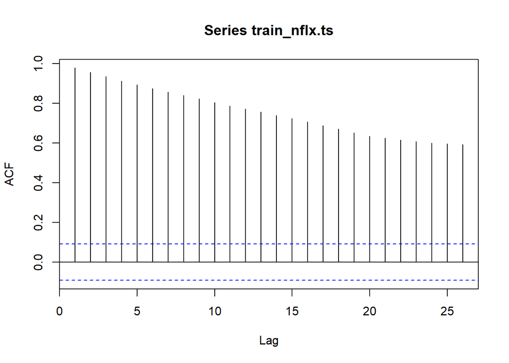

```r
acf(train_nflx.ts)
```

Berdasarkan plot ACF, terlihat bahwa plot ACF data train menurun secara perlahan (*tails of slowly*). Hal ini juga menjadi indikasi bahwa data tidak stasioner dalam rataan. Selain itu data juga tidak membentuk gelombang sinus.

## Uji ADF

```r
tseries::adf.test(train_nflx.ts)
```

```
##
##  Augmented Dickey-Fuller Test
##
## data:  train_nflx.ts
## Dickey-Fuller = -2.7617, Lag order = 7, p-value = 0.2557
## alternative hypothesis: stationary
```

> $H_0$ : Data tidak stasioner dalam rataan

> $H_1$ : Data stasioner dalam rataan

Berdasarkan uji ADF tersebut, didapat *p-value* sebesar $0.2557$ yang lebih besar dari taraf nyata $5\%$ sehingga **tak tolak** $H_0$ dan menandakan bahwa data **tidak stasioner dalam rataan**. Hal ini sesuai dengan hasil eksplorasi menggunakan plot time series dan plot ACF, sehingga ketidakstasioneran model kedepannya harus ditangani.

## Plot Box-Cox

```r
index <- seq(1:round(nrow(nflx) *80/100))
bc = boxcox(train_nflx.ts~index, lambda = seq(-2, 4, by=0.01))
```

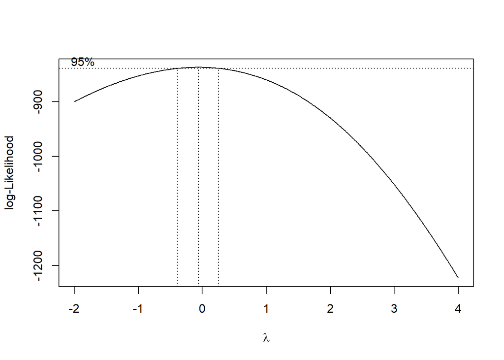

```r
#Nilai Rounded Lambda
lambda_train.nflx <- bc$x[which.max(bc$y)]
#SK
sk_train.nflx <- bc$x[bc$y > max(bc$y) - 1/2 * qchisq(.95,1)]
cat(" Lambda :", lambda_train.nflx,
    "\n\n Selang Kepercyaan 95% \n",
    "Batas Bawah :", min(sk_train.nflx), "\n Batas Atas  :", max(sk_train.nflx) )
```

```
##  Lambda : -0.06
##
##  Selang Kepercyaan 95%
##  Batas Bawah : -0.38
##  Batas Atas  : 0.25
```

Gambar di atas menunjukkan nilai *rounded value* ($\lambda$) optimum sebesar $-0.06$ dan pada selang kepercayaan $95\%$ nilai memiliki batas bawah $-0.38$ dan batas atas $0.25$. Selang tersebut tidak memuat nilai *1* sehingga dapat dikatakan bahwa data saham Netflix tidak stasioner dalam ragam.

# Penanganan Ketidakstasioneran

## Skenario 1 (Ragam baru Rataan)

```r
train_nflx2 <- BoxCox(train_nflx.ts, lambda_train.nflx)
train_nflx2.ts <- ts(train_nflx2)
```

*Pengecekan Stasioner Ragam Kembali Pasca Penanganan Ragam*

```r
index <- seq(1:round(nrow(nflx) *80/100))
bc = boxcox(train_nflx2.ts~index, lambda = seq(-2, 4, by=0.01))
```

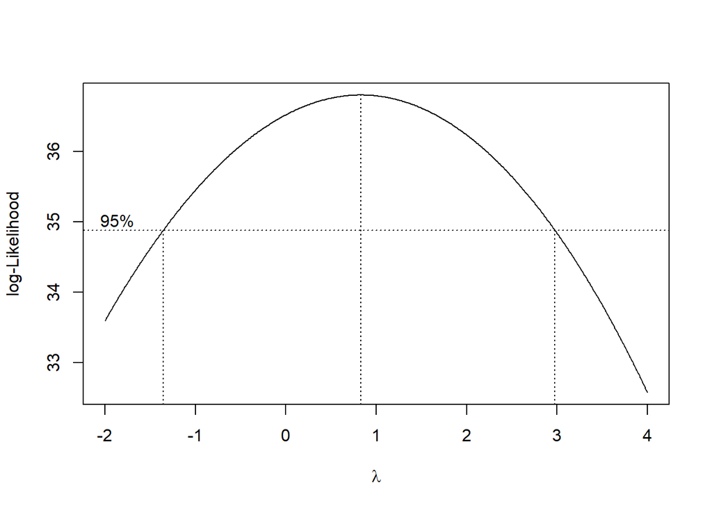

```r
#Nilai Rounded Lambda
lambda_train.nflx2 <- bc$x[which.max(bc$y)]
#SK
sk_train.nflx2 <- bc$x[bc$y > max(bc$y) - 1/2 * qchisq(.95,1)]
cat(" Lambda :", lambda_train.nflx2,
    "\n\n Selang Kepercyaan 95% \n",
    "Batas Bawah :", min(sk_train.nflx2), "\n Batas Atas  :", max(sk_train.nflx2))
```

```
##  Lambda : 0.83
##
##  Selang Kepercyaan 95%
##  Batas Bawah : -1.35
##  Batas Atas  : 2.97
```

Gambar di atas menunjukkan nilai *rounded value* ($\lambda$) optimum sebesar $0.83$ yang mana sudah mendekati lambda *1* dan pada selang kepercayaan $95\%$ nilai memiliki batas bawah $-1.35$ dan batas atas $2.97$. Selang tersebut memuat nilai *1* sehingga dapat dikatakan bahwa data saham Netflix telah stasioner dalam ragam.

*Pengecekan Stasioner Rataan Kembali Pasca Penanganan Ragam*

*Plot ACF*

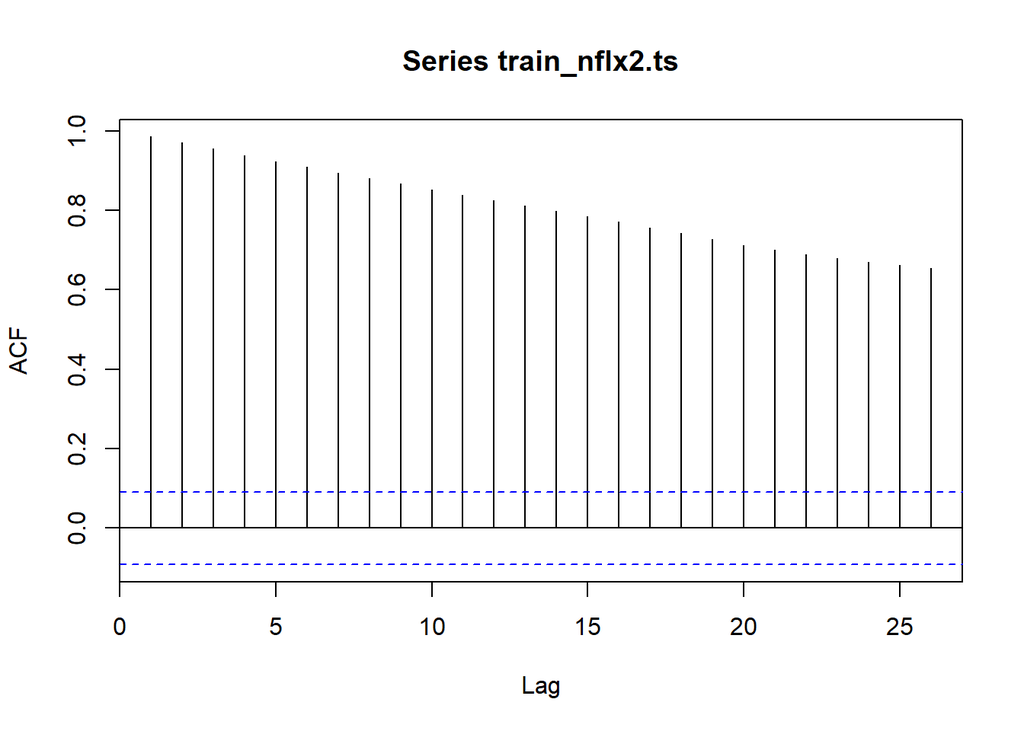

```r
acf(train_nflx2.ts)
```

Berdasarkan plot ACF, terlihat bahwa plot ACF data train menurun secara perlahan (*tails of slowly*). Hal ini juga menjadi indikasi bahwa data pasca penanganan stasioner ragam tidak stasioner dalam rataan. Selain itu data juga tidak membentuk gelombang sinus.

*Uji ADF*

```r
tseries::adf.test(train_nflx2.ts)
```

```
##
##  Augmented Dickey-Fuller Test
##
## data:  train_nflx2.ts
## Dickey-Fuller = -2.1827, Lag order = 7, p-value = 0.5006
## alternative hypothesis: stationary
```

> $H_0$ : Data tidak stasioner dalam rataan

> $H_1$ : Data stasioner dalam rataan

Berdasarkan uji ADF tersebut, didapat *p-value* sebesar $0.5006$ yang lebih besar dari taraf nyata $5\%$ sehingga **tak tolak** $H_0$ dan menandakan bahwa data pasca penanganan stasioner ragam **tidak stasioner dalam rataan**. Hal ini sesuai dengan hasil eksplorasi menggunakan plot time series dan plot ACF, sehingga ketidakstasioneran model kedepannya harus ditangani.

### Penanganan Ketidakstasioneran Rataan

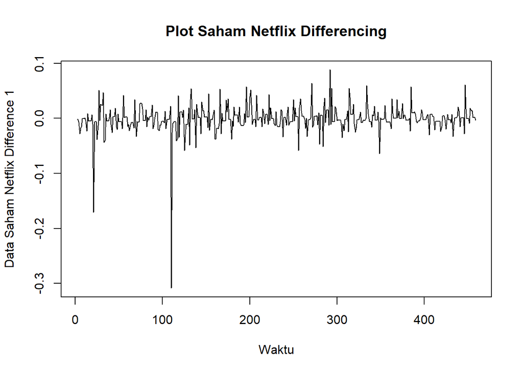

```r
train_nflx2.diff<-diff(train_nflx2.ts,differences = 1)
plot.ts(train_nflx2.diff, lty=1, xlab="Waktu", ylab="Data Saham Netflix Difference 1", main="Plot Saham Netflix Differencing")
```

Berdasarkan plot data deret waktu, terlihat bahwa data sudah mulai tampak stasioner dalam rataan ditandai dengan data bergerak pada nilai tengah tertentu (tidak terdapat trend ataupun musiman pada data). Jadi, data telah stasioner rataan pula

### Plot ACF

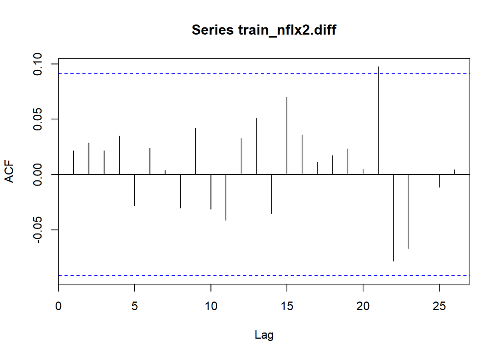

```r
acf(train_nflx2.diff)
```

Berdasarkan plot tersebut, terlihat bahwa plot ACF cuts off pada lag ke 21. Hal ini menandakan data sudah stasioner dalam rataan dan ketidakstasioneran data telah berhasil tertangani.

### Uji ADF

```r
tseries::adf.test(train_nflx2.diff)
```

```
##
##  Augmented Dickey-Fuller Test
##
## data:  train_nflx2.diff
## Dickey-Fuller = -7.6905, Lag order = 7, p-value = 0.01
## alternative hypothesis: stationary
```

$H_0$ : Data tidak stasioner dalam rataan

$H_1$ : Data stasioner dalam rataan

Berdasarkan uji ADF tersebut, didapat *p-value* sebesar 0.01 yang lebih kecil dari taraf nyata 5% sehingga tolak $H_0$ atau data stasioner dalam rataan. Hal ini sesuai dengan hasil eksplorasi menggunakan plot time series dan plot ACF pasca differencing, sehingga dalam hal ini ketidakstasioneran data sudah berhasil ditangani dan dapat dilanjutkan ke pemodelan

## Skenario 2 (Rataan baru Ragam)

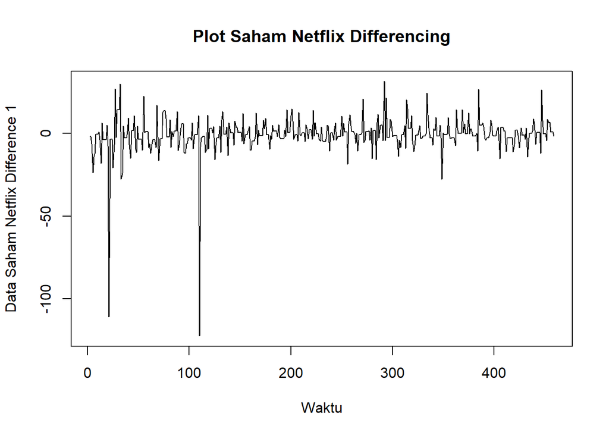

```r
train_nflx.diff<-diff(train_nflx.ts,differences = 1)
plot.ts(train_nflx.diff, lty=1, xlab="Waktu", ylab="Data Saham Netflix Difference 1", main="Plot Saham Netflix Differencing")
```

Berdasarkan plot data deret waktu, terlihat bahwa data sudah mulai tampak stasioner dalam rataan ditandai dengan data bergerak pada nilai tengah tertentu (tidak terdapat trend ataupun musiman pada data). Jadi, data telah stasioner rataan pula

*Pengecekan Stasioner Ragam Kembali Pasca Penanganan Rataan*

### ERROR Karena Boxcox gak bisa buat negatif

```r
#index <- seq(2:(round(nrow(nflx) *80/100)))
#bc = boxcox(train_nflx.diff~index, lambda = seq(-2, 4, by=0.01))
```

```r
#Nilai Rounded Lambda
#lambda_train.nflx.diff <- bc$x[which.max(bc$y)]
#SK
#sk_train.nflx.diff <- bc$x[bc$y > max(bc$y) - 1/2 * qchisq(.95,1)]
#cat(" Lambda :", lambda_train.nflx.diff,
#    "\n\n Selang Kepercyaan 95% \n",
#    "Batas Bawah :", min(sk_train.nflx.diff), "\n Batas Atas  :", max(sk_train.nflx.diff))
```

# Identifikasi Model

## Plot ACF

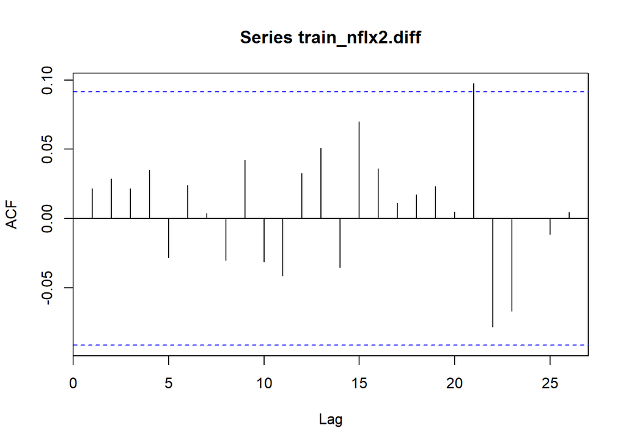

```r
acf(train_nflx2.diff)
```

Berdasarkan plot ACF, tampak bahwa data membentuk gelombang sinus dan cut off di lag 21

## Plot PACF

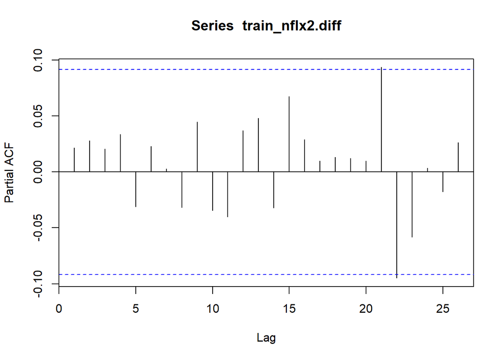

```r
pacf(train_nflx2.diff)
```

## Plot EACF

```r
eacf(train_nflx2.diff)
```

```
## AR/MA
##   0 1 2 3 4 5 6 7 8 9 10 11 12 13
## 0 o o o o o o o o o o o  o  o  o
## 1 x o o o o o o o o o o  o  o  o
## 2 x x o o o o o o o o o  o  o  o
## 3 x x x o o o o o o o o  o  o  o
## 4 x o x o o o o o o o o  o  o  o
## 5 x x o o o o o o o o o  o  o  o
## 6 x x o x o o o o o o o  o  o  o
## 7 o x o o o o o o o o o  o  o  o
```

Berdasarkan plot EACF, didapat beberapa model tentatif, yaitu ARIMA (0,1,1), ARIMA (1,1,1), ARIMA (2,1,2), ARIMA (3,1,3), ARIMA (4,1,3), ARIMA (5,1,3)

# Pendugaan Parameter Model Tentatif

## ARIMA

### ARIMA(0,1,1)

```r
model1=Arima(train_nflx2.diff, order=c(0,1,1),method="ML")
summary(model1) #AIC= -2068.36
```

```
## Series: train_nflx2.diff
## ARIMA(0,1,1)
##
## Coefficients:
##           ma1
##       -0.9883
## s.e.   0.0079
##
## sigma^2 = 0.0006245:  log likelihood = 1036.18
## AIC=-2068.36   AICc=-2068.33   BIC=-2060.11
##
## Training set error measures:
##                       ME       RMSE        MAE      MPE     MAPE      MASE
## Training set 0.001404881 0.02493461 0.01376813 74.17359 142.9082 0.7531782
##                     ACF1
## Training set 0.007130634
```

```r
lmtest::coeftest(model1) #semua signifikan
```

```
##
## z test of coefficients:
##
##       Estimate Std. Error z value  Pr(>|z|)
## ma1 -0.9883051  0.0079475 -124.35 < 2.2e-16 ***
## ---
## Signif. codes:  0 '***' 0.001 '**' 0.01 '*' 0.05 '.' 0.1 ' ' 1
```

### ARIMA(1,1,1)

```r
model2=Arima(train_nflx2.diff, order=c(1,1,1),method="ML")
summary(model2) #AIC= -2066.43
```

```
## Series: train_nflx2.diff
## ARIMA(1,1,1)
##
## Coefficients:
##          ar1      ma1
##       0.0124  -0.9886
## s.e.  0.0472   0.0079
##
## sigma^2 = 0.0006257:  log likelihood = 1036.21
## AIC=-2066.43   AICc=-2066.38   BIC=-2054.05
##
## Training set error measures:
##                       ME       RMSE        MAE      MPE     MAPE      MASE
## Training set 0.001411631 0.02493273 0.01373756 74.42873 142.5879 0.7515054
##                      ACF1
## Training set -0.005302846
```

```r
lmtest::coeftest(model2) #ar1 tidak signifikan
```

```
##
## z test of coefficients:
##
##       Estimate Std. Error  z value Pr(>|z|)
## ar1  0.0123752  0.0472323    0.262   0.7933
## ma1 -0.9885881  0.0079086 -125.002   <2e-16 ***
## ---
## Signif. codes:  0 '***' 0.001 '**' 0.01 '*' 0.05 '.' 0.1 ' ' 1
```

### ARIMA(2,1,2)

```r
model3=Arima(train_nflx2.diff, order=c(2,1,2),method="ML")
summary(model3) #AIC= -2062.6
```

```
## Series: train_nflx2.diff
## ARIMA(2,1,2)
##
## Coefficients:
```

```
##           ar1     ar2      ma1      ma2
##       -0.3605  0.0226  -0.6157  -0.3691
## s.e.      NaN  0.0419      NaN      NaN
##
## sigma^2 = 0.0006283:  log likelihood = 1036.3
## AIC=-2062.6   AICc=-2062.46   BIC=-2041.97
##
## Training set error measures:
##                       ME       RMSE        MAE      MPE     MAPE      MASE
## Training set 0.001418523 0.02492811 0.01372122 71.56565 145.7101 0.7506116
##                     ACF1
## Training set -0.00532128
```

```r
lmtest::coeftest(model3) #tidak ada parameter signifikan dan 3 parameter NaN
```

```
##
## z test of coefficients:
##
##      Estimate Std. Error z value Pr(>|z|)
## ar1 -0.360505        NaN     NaN      NaN
## ar2  0.022581   0.041905  0.5389     0.59
## ma1 -0.615672        NaN     NaN      NaN
## ma2 -0.369074        NaN     NaN      NaN
```

### ARIMA(3,1,3)

```r
model4=Arima(train_nflx2.diff, order=c(3,1,3),method="ML")
summary(model4) #AIC= -2058.78
```

```
## Series: train_nflx2.diff
## ARIMA(3,1,3)
##
## Coefficients:
##           ar1     ar2     ar3      ma1      ma2     ma3
##       -0.2039  0.3994  0.0020  -0.7727  -0.5853  0.3669
## s.e.   0.8925  0.5959  0.0584   0.8908   0.7976  0.6021
##
## sigma^2 = 0.0006308:  log likelihood = 1036.39
## AIC=-2058.78   AICc=-2058.53   BIC=-2029.9
##
## Training set error measures:
##                       ME       RMSE        MAE      MPE     MAPE      MASE
## Training set 0.001430397 0.02492318 0.01370649 70.57684 147.4213 0.7498057
##                      ACF1
## Training set -0.005190578
```

```r
lmtest::coeftest(model4) #tidak ada parameter signifikan
```

```
##
## z test of coefficients:
##
##       Estimate Std. Error z value Pr(>|z|)
## ar1 -0.2038750  0.8925496 -0.2284   0.8193
## ar2  0.3994349  0.5958789  0.6703   0.5026
## ar3  0.0020458  0.0584210  0.0350   0.9721
## ma1 -0.7726549  0.8907692 -0.8674   0.3857
## ma2 -0.5853277  0.7975908 -0.7339   0.4630
## ma3  0.3669122  0.6021296  0.6094   0.5423
```

### ARIMA(4,1,3)

```r
model5=Arima(train_nflx2.diff, order=c(4,1,3),method="ML")
summary(model5) #AIC= -2065.22
```

```
## Series: train_nflx2.diff
## ARIMA(4,1,3)
##
## Coefficients:
##           ar1      ar2     ar3     ar4     ma1      ma2      ma3
##       -1.0583  -0.9402  0.0475  0.0444  0.0961  -0.0737  -0.9893
## s.e.   0.0478   0.0695  0.0698  0.0472  0.0132   0.0130   0.0150
##
## sigma^2 = 0.0006155:  log likelihood = 1040.61
## AIC=-2065.22   AICc=-2064.9   BIC=-2032.22
##
## Training set error measures:
##                      ME       RMSE        MAE      MPE     MAPE      MASE
## Training set 0.00140607 0.02459225 0.01365038 51.82803 200.4206 0.7467364
##                      ACF1
## Training set -0.005099815
```

```r
lmtest::coeftest(model5) #ar3 dan ar4 tidak signifikan
```

```
##
## z test of coefficients:
##
##      Estimate Std. Error  z value  Pr(>|z|)
## ar1 -1.058304   0.047830 -22.1262 < 2.2e-16 ***
## ar2 -0.940245   0.069483 -13.5320 < 2.2e-16 ***
## ar3  0.047503   0.069766   0.6809    0.4959
## ar4  0.044385   0.047249   0.9394    0.3475
## ma1  0.096109   0.013206   7.2779 3.390e-13 ***
## ma2 -0.073733   0.012981  -5.6801 1.346e-08 ***
## ma3 -0.989268   0.015009 -65.9114 < 2.2e-16 ***
## ---
## Signif. codes:  0 '***' 0.001 '**' 0.01 '*' 0.05 '.' 0.1 ' ' 1
```

### ARIMA(5,1,3)

```r
model6=Arima(train_nflx2.diff, order=c(5,1,3),method="ML")
summary(model6) #AIC= -2063.22
```

```
## Series: train_nflx2.diff
## ARIMA(5,1,3)
##
## Coefficients:
##           ar1      ar2     ar3     ar4      ar5     ma1      ma2      ma3
##       -1.0582  -0.9402  0.0463  0.0430  -0.0013  0.0961  -0.0737  -0.9892
## s.e.   0.0479   0.0695  0.0835  0.0696   0.0476  0.0132   0.0132   0.0151
##
## sigma^2 = 0.0006169:  log likelihood = 1040.61
## AIC=-2063.22   AICc=-2062.82   BIC=-2026.1
##
## Training set error measures:
##                      ME       RMSE        MAE      MPE     MAPE      MASE
## Training set 0.00140543 0.02459216 0.01364985 51.84311 201.0254 0.7467077
##                     ACF1
## Training set -0.00512844
```

```r
lmtest::coeftest(model6) #ar3, ar4, dan ar5 tidak signifikan
```

```
##
## z test of coefficients:
##
##       Estimate Std. Error  z value  Pr(>|z|)
## ar1 -1.0582474  0.0478864 -22.0991 < 2.2e-16 ***
## ar2 -0.9402462  0.0694846 -13.5317 < 2.2e-16 ***
## ar3  0.0462820  0.0835473   0.5540    0.5796
## ar4  0.0430345  0.0696152   0.6182    0.5365
## ar5 -0.0012518  0.0476081  -0.0263    0.9790
## ma1  0.0961089  0.0132164   7.2719 3.544e-13 ***
## ma2 -0.0736719  0.0131961  -5.5828 2.366e-08 ***
## ma3 -0.9892397  0.0150665 -65.6580 < 2.2e-16 ***
## ---
## Signif. codes:  0 '***' 0.001 '**' 0.01 '*' 0.05 '.' 0.1 ' ' 1
```

## ARIMA dengan Kombinasi Intercept dan Drift

### Model Tanpa Intersept dan Drift (Data train dikasih diff)

####ARIMA(0,1,1) aic = -2079.41; tidak ada signifikan

```r
model1a <- arima(train_nflx2, order=c(0,1,1), method="ML")
lmtest::coeftest(model1a)
```

```
##
## z test of coefficients:
##
##     Estimate Std. Error z value Pr(>|z|)
## ma1 0.021282   0.045407  0.4687   0.6393
```

```r
model1a
```

```
##
## Call:
## arima(x = train_nflx2, order = c(0, 1, 1), method = "ML")
##
## Coefficients:
##          ma1
##       0.0213
## s.e.  0.0454
##
## sigma^2 estimated as 0.0006221:  log likelihood = 1040.7,  aic = -2079.41
```

####ARIMA(0,1,2) aic = -2077.76; tidak ada signifikan

```r
model1b <- arima(train_nflx2, order=c(0,1,2), method="ML")
lmtest::coeftest(model1b)
```

```
##
## z test of coefficients:
##
##     Estimate Std. Error z value Pr(>|z|)
## ma1 0.020723   0.046728  0.4435   0.6574
## ma2 0.026594   0.045056  0.5902   0.5550
```

```r
model1b
```

```
##
## Call:
## arima(x = train_nflx2, order = c(0, 1, 2), method = "ML")
##
## Coefficients:
##          ma1     ma2
##       0.0207  0.0266
## s.e.  0.0467  0.0451
##
## sigma^2 estimated as 0.0006216:  log likelihood = 1040.88,  aic = -2077.76
```

####ARIMA(1,1,1) aic = -2078.09; tidak ada signifikan

```r
model2a <- arima(train_nflx2, order=c(1,1,1), method="ML")
lmtest::coeftest(model2a)
```

```
##
## z test of coefficients:
##
##     Estimate Std. Error z value Pr(>|z|)
## ar1  0.76037    0.88499  0.8592   0.3902
## ma1 -0.73175    0.92367 -0.7922   0.4282
```

```r
model2a
```

```
##
## Call:
## arima(x = train_nflx2, order = c(1, 1, 1), method = "ML")
##
## Coefficients:
##          ar1      ma1
##       0.7604  -0.7318
## s.e.  0.8850   0.9237
##
## sigma^2 estimated as 0.0006212:  log likelihood = 1041.05,  aic = -2078.09
```

####ARIMA(1,1,2) aic = -2076.15; tidak ada signifikan

```r
model2b <- arima(train_nflx2, order=c(1,1,2), method="ML")
lmtest::coeftest(model2b)
```

```
##
## z test of coefficients:
##
##      Estimate Std. Error z value Pr(>|z|)
## ar1  0.578546   0.710169  0.8147   0.4153
## ma1 -0.557747   0.711093 -0.7844   0.4328
## ma2  0.021258   0.055089  0.3859   0.6996
```

```r
model2b
```

```
##
## Call:
## arima(x = train_nflx2, order = c(1, 1, 2), method = "ML")
##
## Coefficients:
##          ar1      ma1     ma2
##       0.5785  -0.5577  0.0213
## s.e.  0.7102   0.7111  0.0551
##
## sigma^2 estimated as 0.0006211:  log likelihood = 1041.08,  aic = -2076.15
```

####ARIMA(2,1,2) aic = -2074.24; tidak ada signifikan

```r
model3a <- arima(train_nflx2, order=c(2,1,2), method="ML")
lmtest::coeftest(model3a)
```

```
##
## z test of coefficients:
##
##      Estimate Std. Error z value Pr(>|z|)
## ar1  0.090084        NaN     NaN      NaN
## ar2  0.525537        NaN     NaN      NaN
## ma1 -0.071324        NaN     NaN      NaN
## ma2 -0.493579        NaN     NaN      NaN
```

```r
model3a
```

```
##
## Call:
## arima(x = train_nflx2, order = c(2, 1, 2), method = "ML")
##
## Coefficients:
```

```
##          ar1     ar2      ma1      ma2
##       0.0901  0.5255  -0.0713  -0.4936
## s.e.     NaN     NaN      NaN      NaN
##
## sigma^2 estimated as 0.000621:  log likelihood = 1041.12,  aic = -2074.24
```

####ARIMA(2,1,3) aic = -2072.16; tidak ada signifikan

```r
model3b <- arima(train_nflx2, order=c(2,1,3), method="ML")
lmtest::coeftest(model3b)
```

```
##
## z test of coefficients:
##
##       Estimate Std. Error z value Pr(>|z|)
## ar1  0.3012176        NaN     NaN      NaN
## ar2  0.1952950        NaN     NaN      NaN
## ma1 -0.2807801        NaN     NaN      NaN
## ma2 -0.1700089        NaN     NaN      NaN
## ma3  0.0080924  0.0488580  0.1656   0.8684
```

```r
model3b
```

```
##
## Call:
## arima(x = train_nflx2, order = c(2, 1, 3), method = "ML")
##
## Coefficients:
```

```
##          ar1     ar2      ma1    ma2     ma3
##       0.3012  0.1953  -0.2808  -0.17  0.0081
## s.e.     NaN     NaN      NaN    NaN  0.0489
##
## sigma^2 estimated as 0.0006211:  log likelihood = 1041.08,  aic = -2072.16
```

####ARIMA(3,1,3) aic = -2070.12; tidak ada signifikan

```r
model4a <- arima(train_nflx2, order=c(3,1,3), method="ML")
lmtest::coeftest(model4a)
```

```
##
## z test of coefficients:
##
##      Estimate Std. Error z value Pr(>|z|)
## ar1  0.165596   1.226122  0.1351   0.8926
## ar2  0.081912   0.264144  0.3101   0.7565
## ar3  0.102579   0.734011  0.1398   0.8889
## ma1 -0.142541   1.246008 -0.1144   0.9089
## ma2 -0.057854   0.347718 -0.1664   0.8679
## ma3 -0.083476   0.777144 -0.1074   0.9145
```

```r
model4a
```

```
##
## Call:
## arima(x = train_nflx2, order = c(3, 1, 3), method = "ML")
##
## Coefficients:
##          ar1     ar2     ar3      ma1      ma2      ma3
##       0.1656  0.0819  0.1026  -0.1425  -0.0579  -0.0835
## s.e.  1.2261  0.2641  0.7340   1.2460   0.3477   0.7771
##
## sigma^2 estimated as 0.0006211:  log likelihood = 1041.06,  aic = -2070.12
```

####ARIMA(3,1,4) aic = -2076.25; tidak ada signifikan

```r
model4b <- arima(train_nflx2, order=c(3,1,4), method="ML")
lmtest::coeftest(model4b)
```

```
##
## z test of coefficients:
##
##      Estimate Std. Error z value Pr(>|z|)
## ar1 -0.249473        NaN     NaN      NaN
## ar2 -0.127240        NaN     NaN      NaN
## ar3  0.796561        NaN     NaN      NaN
## ma1  0.285007        NaN     NaN      NaN
## ma2  0.152252        NaN     NaN      NaN
## ma3 -0.777115        NaN     NaN      NaN
## ma4  0.021826   0.035760  0.6104   0.5416
```

```r
model4b
```

```
##
## Call:
## arima(x = train_nflx2, order = c(3, 1, 4), method = "ML")
##
## Coefficients:
```

```
##           ar1      ar2     ar3    ma1     ma2      ma3     ma4
##       -0.2495  -0.1272  0.7966  0.285  0.1523  -0.7771  0.0218
## s.e.      NaN      NaN     NaN    NaN     NaN      NaN  0.0358
##
## sigma^2 estimated as 0.0006053:  log likelihood = 1045.12,  aic = -2076.25
```

####ARIMA(4,1,3) aic = -2076.24; tidak ada signifikan

```r
model5a <- arima(train_nflx2, order=c(4,1,3), method="ML")
lmtest::coeftest(model5a)
```

```
##
## z test of coefficients:
##
##      Estimate Std. Error z value Pr(>|z|)
## ar1 -0.247685        NaN     NaN      NaN
## ar2 -0.104154        NaN     NaN      NaN
## ar3  0.820649        NaN     NaN      NaN
## ar4  0.020794   0.037738   0.551   0.5816
## ma1  0.282303        NaN     NaN      NaN
## ma2  0.127421        NaN     NaN      NaN
## ma3 -0.803565        NaN     NaN      NaN
```

```r
model5a
```

```
##
## Call:
## arima(x = train_nflx2, order = c(4, 1, 3), method = "ML")
##
## Coefficients:
```

```
##           ar1      ar2     ar3     ar4     ma1     ma2      ma3
##       -0.2477  -0.1042  0.8206  0.0208  0.2823  0.1274  -0.8036
## s.e.      NaN      NaN     NaN  0.0377     NaN     NaN      NaN
##
## sigma^2 estimated as 0.0006053:  log likelihood = 1045.12,  aic = -2076.24
```

####ARIMA(4,1,4) aic = -2073.15; ar3 dan ma3 signifikan 5%

```r
model5b <- arima(train_nflx2, order=c(4,1,4), method="ML")
lmtest::coeftest(model5b)
```

```
##
## z test of coefficients:
##
##      Estimate Std. Error z value Pr(>|z|)
## ar1 -0.471942   1.299302 -0.3632  0.71644
## ar2  0.106855   0.654843  0.1632  0.87038
## ar3  0.903475   0.402302  2.2458  0.02472 *
## ar4  0.145431   1.038771  0.1400  0.88866
## ma1  0.505292   1.304656  0.3873  0.69853
## ma2 -0.072206   0.752558 -0.0959  0.92356
## ma3 -0.911952   0.436665 -2.0884  0.03676 *
## ma4 -0.127726   1.047801 -0.1219  0.90298
## ---
## Signif. codes:  0 '***' 0.001 '**' 0.01 '*' 0.05 '.' 0.1 ' ' 1
```

```r
model5b
```

```
##
## Call:
## arima(x = train_nflx2, order = c(4, 1, 4), method = "ML")
##
## Coefficients:
##           ar1     ar2     ar3     ar4     ma1      ma2      ma3      ma4
##       -0.4719  0.1069  0.9035  0.1454  0.5053  -0.0722  -0.9120  -0.1277
## s.e.   1.2993  0.6548  0.4023  1.0388  1.3047   0.7526   0.4367   1.0478
##
## sigma^2 estimated as 0.0006068:  log likelihood = 1044.58,  aic = -2073.15
```

####ARIMA(4,1,5) aic = -2071.61; tidak ada signifikan

```r
model5c <- arima(train_nflx2, order=c(4,1,5), method="ML")
lmtest::coeftest(model5c)
```

```
##
## z test of coefficients:
##
##      Estimate Std. Error z value Pr(>|z|)
## ar1  0.300673        NaN     NaN      NaN
## ar2  0.168109   0.125896  1.3353  0.18178
## ar3  0.565043        NaN     NaN      NaN
## ar4 -0.702009        NaN     NaN      NaN
## ma1 -0.265451        NaN     NaN      NaN
## ma2 -0.150169   0.084164 -1.7843  0.07438 .
## ma3 -0.580198        NaN     NaN      NaN
## ma4  0.740703        NaN     NaN      NaN
## ma5 -0.017436        NaN     NaN      NaN
## ---
## Signif. codes:  0 '***' 0.001 '**' 0.01 '*' 0.05 '.' 0.1 ' ' 1
```

```r
model5c
```

```
##
## Call:
## arima(x = train_nflx2, order = c(4, 1, 5), method = "ML")
##
## Coefficients:
```

```
##          ar1     ar2    ar3     ar4      ma1      ma2      ma3     ma4      ma5
##       0.3007  0.1681  0.565  -0.702  -0.2655  -0.1502  -0.5802  0.7407  -0.0174
## s.e.     NaN  0.1259    NaN     NaN      NaN   0.0842      NaN     NaN      NaN
##
## sigma^2 estimated as 0.0006064:  log likelihood = 1044.81,  aic = -2071.61
```

####ARIMA(5,1,3) aic = -2075.03; ar3, ma1, dan ma3 signifikan

```r
model6a <- arima(train_nflx2, order=c(5,1,3), method="ML")
lmtest::coeftest(model6a)
```

```
##
## z test of coefficients:
##
##       Estimate Std. Error  z value Pr(>|z|)
## ar1 -0.0731708  0.0664487  -1.1012  0.27083
## ar2  0.1030244  0.0681778   1.5111  0.13076
## ar3  0.9727986  0.0407155  23.8926  < 2e-16 ***
## ar4 -0.0028069  0.0477975  -0.0587  0.95317
## ar5 -0.0443424  0.0473263  -0.9370  0.34878
## ma1  0.1075435  0.0485481   2.2152  0.02675 *
## ma2 -0.0619818  0.0524367  -1.1820  0.23719
## ma3 -0.9781507  0.0485401 -20.1514  < 2e-16 ***
## ---
## Signif. codes:  0 '***' 0.001 '**' 0.01 '*' 0.05 '.' 0.1 ' ' 1
```

```r
model6a
```

```
##
## Call:
## arima(x = train_nflx2, order = c(5, 1, 3), method = "ML")
##
## Coefficients:
##           ar1     ar2     ar3      ar4      ar5     ma1      ma2      ma3
##       -0.0732  0.1030  0.9728  -0.0028  -0.0443  0.1075  -0.0620  -0.9782
## s.e.   0.0664  0.0682  0.0407   0.0478   0.0473  0.0485   0.0524   0.0485
##
## sigma^2 estimated as 0.0006041:  log likelihood = 1045.51,  aic = -2075.03
```

####ARIMA(5,1,4) aic = -2072.44; ar3 dan ma3 signifikan

```r
model6b <- arima(train_nflx2, order=c(5,1,4), method="ML")
lmtest::coeftest(model6b)
```

```
##
## z test of coefficients:
##
##       Estimate Std. Error z value  Pr(>|z|)
## ar1  0.3400239  1.5394817  0.2209    0.8252
## ar2  0.0209331  0.3170676  0.0660    0.9474
## ar3  0.8422660  0.0875940  9.6156 < 2.2e-16 ***
## ar4 -0.5006060  1.2415793 -0.4032    0.6868
## ar5 -0.0309029  0.0537141 -0.5753    0.5651
## ma1 -0.3049818  1.5345669 -0.1987    0.8425
## ma2 -0.0024934  0.4253160 -0.0059    0.9953
## ma3 -0.8394986  0.1444147 -5.8131 6.132e-09 ***
## ma4  0.5076472  1.2210995  0.4157    0.6776
## ---
## Signif. codes:  0 '***' 0.001 '**' 0.01 '*' 0.05 '.' 0.1 ' ' 1
```

```r
model6b
```

```
##
## Call:
## arima(x = train_nflx2, order = c(5, 1, 4), method = "ML")
##
## Coefficients:
##          ar1     ar2     ar3      ar4      ar5      ma1      ma2      ma3
##       0.3400  0.0209  0.8423  -0.5006  -0.0309  -0.3050  -0.0025  -0.8395
## s.e.  1.5395  0.3171  0.0876   1.2416   0.0537   1.5346   0.4253   0.1444
##          ma4
##       0.5076
## s.e.  1.2211
##
## sigma^2 estimated as 0.000605:  log likelihood = 1045.22,  aic = -2072.44
```

####ARIMA(5,1,5) aic = -2069.55; tidak ada signifikan

```r
model6c <- arima(train_nflx2, order=c(5,1,5), method="ML")
lmtest::coeftest(model6c)
```

```
##
## z test of coefficients:
##
##     Estimate Std. Error z value Pr(>|z|)
## ar1  0.14972        NaN     NaN      NaN
## ar2 -0.14359        NaN     NaN      NaN
## ar3  0.71603        NaN     NaN      NaN
## ar4 -0.27514        NaN     NaN      NaN
## ar5  0.42899        NaN     NaN      NaN
## ma1 -0.11895        NaN     NaN      NaN
## ma2  0.17044        NaN     NaN      NaN
## ma3 -0.71837        NaN     NaN      NaN
## ma4  0.30432        NaN     NaN      NaN
## ma5 -0.47312        NaN     NaN      NaN
```

```r
model6c
```

```
##
## Call:
## arima(x = train_nflx2, order = c(5, 1, 5), method = "ML")
##
## Coefficients:
```

```
##          ar1      ar2    ar3      ar4    ar5     ma1     ma2      ma3     ma4
##       0.1497  -0.1436  0.716  -0.2751  0.429  -0.119  0.1704  -0.7184  0.3043
## s.e.     NaN      NaN    NaN      NaN    NaN     NaN     NaN      NaN     NaN
##           ma5
##       -0.4731
## s.e.      NaN
##
## sigma^2 estimated as 0.0006064:  log likelihood = 1044.78,  aic = -2069.55
```

### Model Dengan Intercept Tanpa Drift (data diff tanpa diff)

####ARIMA(0,1,1), aic = -2077.89; Tidak signifikan

```r
model1a <- arima(train_nflx2.diff, order=c(0,0,1), method="ML")
lmtest::coeftest(model1a)
```

```
##
## z test of coefficients:
##
##              Estimate  Std. Error z value Pr(>|z|)
## ma1        0.02030517  0.04544776  0.4468   0.6550
## intercept -0.00083112  0.00118934 -0.6988   0.4847
```

```r
model1a
```

```
##
## Call:
## arima(x = train_nflx2.diff, order = c(0, 0, 1), method = "ML")
##
## Coefficients:
##          ma1  intercept
##       0.0203    -0.0008
## s.e.  0.0454     0.0012
##
## sigma^2 estimated as 0.0006214:  log likelihood = 1040.95,  aic = -2077.89
```

####ARIMA(0,1,2) aic = -2076.22; tidak ada signifikan

```r
model1b <- arima(train_nflx2.diff, order=c(0,0,2), method="ML")
lmtest::coeftest(model1b)
```

```
##
## z test of coefficients:
##
##              Estimate  Std. Error z value Pr(>|z|)
## ma1        0.01978592  0.04672414  0.4235   0.6720
## ma2        0.02571688  0.04509148  0.5703   0.5685
## intercept -0.00083111  0.00121811 -0.6823   0.4951
```

```r
model1b
```

```
##
## Call:
## arima(x = train_nflx2.diff, order = c(0, 0, 2), method = "ML")
##
## Coefficients:
##          ma1     ma2  intercept
##       0.0198  0.0257    -0.0008
## s.e.  0.0467  0.0451     0.0012
##
## sigma^2 estimated as 0.000621:  log likelihood = 1041.11,  aic = -2076.22
```

####ARIMA(1,1,1) aic = -2076.49; tidak ada signifikan

```r
model2a <- arima(train_nflx2.diff, order=c(1,0,1), method="ML")
lmtest::coeftest(model2a)
```

```
##
## z test of coefficients:
##
##              Estimate  Std. Error z value Pr(>|z|)
## ar1        0.72390334  0.60839493  1.1899   0.2341
## ma1       -0.69548450  0.62997255 -1.1040   0.2696
## intercept -0.00082948  0.00128380 -0.6461   0.5182
```

```r
model2a
```

```
##
## Call:
## arima(x = train_nflx2.diff, order = c(1, 0, 1), method = "ML")
##
## Coefficients:
##          ar1      ma1  intercept
##       0.7239  -0.6955    -0.0008
## s.e.  0.6084   0.6300     0.0013
##
## sigma^2 estimated as 0.0006206:  log likelihood = 1041.25,  aic = -2076.49
```

####ARIMA(1,1,2) aic = -2074.58; tidak ada signifikan

```r
model2b <- arima(train_nflx2.diff, order=c(1,0,2), method="ML")
lmtest::coeftest(model2b)
```

```
##
## z test of coefficients:
##
##              Estimate  Std. Error z value Pr(>|z|)
## ar1        0.57163490  0.68236932  0.8377   0.4022
## ma1       -0.55199358  0.68332522 -0.8078   0.4192
## ma2        0.02079107  0.05401209  0.3849   0.7003
## intercept -0.00082823  0.00127400 -0.6501   0.5156
```

```r
model2b
```

```
##
## Call:
## arima(x = train_nflx2.diff, order = c(1, 0, 2), method = "ML")
##
## Coefficients:
##          ar1      ma1     ma2  intercept
##       0.5716  -0.5520  0.0208    -0.0008
## s.e.  0.6824   0.6833  0.0540     0.0013
##
## sigma^2 estimated as 0.0006205:  log likelihood = 1041.29,  aic = -2074.58
```

####ARIMA(2,1,2) aic = -2072.64; tidak ada signifikan

```r
model3a <- arima(train_nflx2.diff, order=c(2,0,2), method="ML")
lmtest::coeftest(model3a)
```

```
##
## z test of coefficients:
##
##              Estimate  Std. Error z value Pr(>|z|)
## ar1        0.10230078  1.21709718  0.0841   0.9330
## ar2        0.46710213  0.86971760  0.5371   0.5912
## ma1       -0.08372873  1.23371111 -0.0679   0.9459
## ma2       -0.43584091  0.87312386 -0.4992   0.6177
## intercept -0.00083773  0.00129828 -0.6453   0.5188
```

```r
model3a
```

```
##
## Call:
## arima(x = train_nflx2.diff, order = c(2, 0, 2), method = "ML")
##
## Coefficients:
##          ar1     ar2      ma1      ma2  intercept
##       0.1023  0.4671  -0.0837  -0.4358    -0.0008
## s.e.  1.2171  0.8697   1.2337   0.8731     0.0013
##
## sigma^2 estimated as 0.0006204:  log likelihood = 1041.32,  aic = -2072.64
```

####ARIMA(2,1,3) aic = -2070.58; tidak ada signifikan

```r
model3b <- arima(train_nflx2.diff, order=c(2,0,3), method="ML")
lmtest::coeftest(model3b)
```

```
##
## z test of coefficients:
##
##              Estimate  Std. Error z value Pr(>|z|)
## ar1        0.28650856         NaN     NaN      NaN
## ar2        0.16304269         NaN     NaN      NaN
## ma1       -0.26706717         NaN     NaN      NaN
## ma2       -0.13837554         NaN     NaN      NaN
## ma3        0.00975262  0.04590240  0.2125   0.8317
## intercept -0.00084172  0.00127798 -0.6586   0.5101
```

```r
model3b
```

```
##
## Call:
## arima(x = train_nflx2.diff, order = c(2, 0, 3), method = "ML")
##
## Coefficients:
```

```
##          ar1    ar2      ma1      ma2     ma3  intercept
##       0.2865  0.163  -0.2671  -0.1384  0.0098    -0.0008
## s.e.     NaN    NaN      NaN      NaN  0.0459     0.0013
##
## sigma^2 estimated as 0.0006205:  log likelihood = 1041.29,  aic = -2070.58
```

```r
model4a <- arima(train_nflx2.diff, order=c(3,0,3), method="ML")
lmtest::coeftest(model4a)
```

```
##
## z test of coefficients:
##
##              Estimate  Std. Error z value Pr(>|z|)
## ar1        0.50162695  3.11123935  0.1612   0.8719
## ar2       -0.20100961  1.48542469 -0.1353   0.8924
## ar3        0.13421676  2.08133918  0.0645   0.9486
## ma1       -0.48126151  3.12775488 -0.1539   0.8777
## ma2        0.21463658  1.46330037  0.1467   0.8834
## ma3       -0.11172635  1.95623015 -0.0571   0.9545
## intercept -0.00082779  0.00128028 -0.6466   0.5179
```

```r
model4a
```

```
##
## Call:
## arima(x = train_nflx2.diff, order = c(3, 0, 3), method = "ML")
##
## Coefficients:
##          ar1      ar2     ar3      ma1     ma2      ma3  intercept
##       0.5016  -0.2010  0.1342  -0.4813  0.2146  -0.1117    -0.0008
## s.e.  3.1112   1.4854  2.0813   3.1278  1.4633   1.9562     0.0013
##
## sigma^2 estimated as 0.0006204:  log likelihood = 1041.33,  aic = -2068.66
```

####ARIMA(3,1,4) aic = -2073.67; tidak ada signifikan

```r
model4b <- arima(train_nflx2.diff, order=c(3,0,4), method="ML")
lmtest::coeftest(model4b)
```

```
##
## z test of coefficients:
##
##              Estimate  Std. Error z value Pr(>|z|)
## ar1       -0.59589388         NaN     NaN      NaN
## ar2       -0.19782403         NaN     NaN      NaN
## ar3        0.59877526         NaN     NaN      NaN
## ma1        0.62895230         NaN     NaN      NaN
## ma2        0.25189591         NaN     NaN      NaN
## ma3       -0.57608736         NaN     NaN      NaN
## ma4        0.04052651  0.04554812  0.8898   0.3736
## intercept -0.00083432  0.00129526 -0.6441   0.5195
```

```r
model4b
```

```
##
## Call:
## arima(x = train_nflx2.diff, order = c(3, 0, 4), method = "ML")
##
## Coefficients:
```

```
##           ar1      ar2     ar3    ma1     ma2      ma3     ma4  intercept
##       -0.5959  -0.1978  0.5988  0.629  0.2519  -0.5761  0.0405    -0.0008
## s.e.      NaN      NaN     NaN    NaN     NaN      NaN  0.0455     0.0013
##
## sigma^2 estimated as 0.0006064:  log likelihood = 1044.83,  aic = -2073.67
```

####ARIMA(4,1,3) aic = -2073.61; tidak ada signifikan

```r
model5a <- arima(train_nflx2.diff, order=c(4,0,3), method="ML")
lmtest::coeftest(model5a)
```

```
##
## z test of coefficients:
##
##              Estimate  Std. Error z value Pr(>|z|)
## ar1       -0.55689915         NaN     NaN      NaN
## ar2       -0.11502269         NaN     NaN      NaN
## ar3        0.67813223         NaN     NaN      NaN
## ar4        0.03318642  0.04417956  0.7512   0.4525
## ma1        0.59188651         NaN     NaN      NaN
## ma2        0.16450934         NaN     NaN      NaN
## ma3       -0.66468220         NaN     NaN      NaN
## intercept -0.00080379  0.00130706 -0.6150   0.5386
```

```r
model5a
```

```
##
## Call:
## arima(x = train_nflx2.diff, order = c(4, 0, 3), method = "ML")
##
## Coefficients:
```

```
##           ar1     ar2     ar3     ar4     ma1     ma2      ma3  intercept
##       -0.5569  -0.115  0.6781  0.0332  0.5919  0.1645  -0.6647    -0.0008
## s.e.      NaN     NaN     NaN  0.0442     NaN     NaN      NaN     0.0013
##
## sigma^2 estimated as 0.0006062:  log likelihood = 1044.81,  aic = -2073.61
```

####ARIMA(4,1,4) aic = -2071.54; tidak ada signifikan

```r
model5b <- arima(train_nflx2.diff, order=c(4,0,4), method="ML")
lmtest::coeftest(model5b)
```

```
##
## z test of coefficients:
##
##              Estimate  Std. Error z value Pr(>|z|)
## ar1       -0.56231911  0.94219855 -0.5968   0.5506
## ar2        0.04572253         NaN     NaN      NaN
## ar3        0.87736724         NaN     NaN      NaN
## ar4        0.19313198  0.81132887  0.2380   0.8118
## ma1        0.59528663  0.93820413  0.6345   0.5258
## ma2       -0.00568298         NaN     NaN      NaN
## ma3       -0.88060561         NaN     NaN      NaN
## ma4       -0.17441953  0.82286911 -0.2120   0.8321
## intercept -0.00083177  0.00137498 -0.6049   0.5452
```

```r
model5b
```

```
##
## Call:
## arima(x = train_nflx2.diff, order = c(4, 0, 4), method = "ML")
##
## Coefficients:
```

```
##           ar1     ar2     ar3     ar4     ma1      ma2      ma3      ma4
##       -0.5623  0.0457  0.8774  0.1931  0.5953  -0.0057  -0.8806  -0.1744
## s.e.   0.9422     NaN     NaN  0.8113  0.9382      NaN      NaN   0.8229
##       intercept
##         -0.0008
## s.e.     0.0014
##
## sigma^2 estimated as 0.0006063:  log likelihood = 1044.77,  aic = -2071.54
```

```r
model5c <- arima(train_nflx2.diff, order=c(4,0,5), method="ML")
lmtest::coeftest(model5c)
```

```
##
## z test of coefficients:
##
##             Estimate Std. Error z value  Pr(>|z|)
## ar1       -0.0071300  1.3326398 -0.0054    0.9957
## ar2        0.0589325  0.0904207  0.6518    0.5146
## ar3        0.9640201  0.1087662  8.8632 < 2.2e-16 ***
## ar4       -0.0667345  1.3144410 -0.0508    0.9595
## ma1        0.0415279  1.3332451  0.0311    0.9752
## ma2       -0.0227191  0.1427055 -0.1592    0.8735
## ma3       -0.9672362  0.1188450 -8.1386 3.998e-16 ***
## ma4        0.0632935  1.3254243  0.0478    0.9619
## ma5       -0.0425468  0.0469154 -0.9069    0.3645
## intercept -0.0010176  0.0016504 -0.6166    0.5375
## ---
## Signif. codes:  0 '***' 0.001 '**' 0.01 '*' 0.05 '.' 0.1 ' ' 1
```

```r
model5c
```

```
##
## Call:
## arima(x = train_nflx2.diff, order = c(4, 0, 5), method = "ML")
##
## Coefficients:
##           ar1     ar2     ar3      ar4     ma1      ma2      ma3     ma4
##       -0.0071  0.0589  0.9640  -0.0667  0.0415  -0.0227  -0.9672  0.0633
## s.e.   1.3326  0.0904  0.1088   1.3144  1.3332   0.1427   0.1188  1.3254
##           ma5  intercept
##       -0.0425    -0.0010
## s.e.   0.0469     0.0017
##
## sigma^2 estimated as 0.0006037:  log likelihood = 1045.65,  aic = -2071.31
```

####ARIMA(5,1,3) aic = -2073.31; ada yang tidak signifikan

```r
model6a <- arima(train_nflx2.diff, order=c(5,0,3), method="ML")
lmtest::coeftest(model6a)
```

```
##
## z test of coefficients:
##
##              Estimate  Std. Error  z value  Pr(>|z|)
## ar1       -0.07980905  0.05549909  -1.4380  0.150427
## ar2        0.09590810  0.05323817   1.8015  0.071626 .
## ar3        0.96819068  0.03187184  30.3776 < 2.2e-16 ***
## ar4       -0.00239765  0.04748366  -0.0505  0.959729
## ar5       -0.04436045  0.04692331  -0.9454  0.344464
## ma1        0.11242813  0.03533781   3.1815  0.001465 **
## ma2       -0.05520974  0.03249913  -1.6988  0.089356 .
## ma3       -0.97234290  0.03315115 -29.3306 < 2.2e-16 ***
## intercept -0.00090338  0.00153489  -0.5886  0.556153
## ---
## Signif. codes:  0 '***' 0.001 '**' 0.01 '*' 0.05 '.' 0.1 ' ' 1
```

```r
model6a
```

```
##
## Call:
## arima(x = train_nflx2.diff, order = c(5, 0, 3), method = "ML")
##
## Coefficients:
##           ar1     ar2     ar3      ar4      ar5     ma1      ma2      ma3
##       -0.0798  0.0959  0.9682  -0.0024  -0.0444  0.1124  -0.0552  -0.9723
## s.e.   0.0555  0.0532  0.0319   0.0475   0.0469  0.0353   0.0325   0.0332
##       intercept
##         -0.0009
## s.e.     0.0015
##
## sigma^2 estimated as 0.0006038:  log likelihood = 1045.66,  aic = -2073.31
```

```r
model6b <- arima(train_nflx2.diff, order=c(5,0,4), method="ML")
lmtest::coeftest(model6b)
```

```
##
## z test of coefficients:
##
##              Estimate  Std. Error z value  Pr(>|z|)
## ar1        0.45783827         NaN     NaN       NaN
## ar2       -0.05105830  0.19337017 -0.2640    0.7917
## ar3        0.75841079  0.16131650  4.7014 2.584e-06 ***
## ar4       -0.68903760  0.09962541 -6.9163 4.636e-12 ***
## ar5       -0.02627177  0.05568875 -0.4718    0.6371
## ma1       -0.42561841         NaN     NaN       NaN
## ma2        0.06167658  0.17871190  0.3451    0.7300
## ma3       -0.75042861  0.18823008 -3.9868 6.698e-05 ***
## ma4        0.70057679  0.11590495  6.0444 1.500e-09 ***
## intercept -0.00087879  0.00122477 -0.7175    0.4731
## ---
## Signif. codes:  0 '***' 0.001 '**' 0.01 '*' 0.05 '.' 0.1 ' ' 1
```

```r
model6b
```

```
##
## Call:
## arima(x = train_nflx2.diff, order = c(5, 0, 4), method = "ML")
##
## Coefficients:
```

```
##          ar1      ar2     ar3      ar4      ar5      ma1     ma2      ma3
##       0.4578  -0.0511  0.7584  -0.6890  -0.0263  -0.4256  0.0617  -0.7504
## s.e.     NaN   0.1934  0.1613   0.0996   0.0557      NaN  0.1787   0.1882
##          ma4  intercept
##       0.7006    -0.0009
## s.e.  0.1159     0.0012
##
## sigma^2 estimated as 0.000604:  log likelihood = 1045.58,  aic = -2071.16
```

####ARIMA(5,1,5) aic = -2067.73; tidak ada signifikan

```r
model6c <- arima(train_nflx2.diff, order=c(5,0,5), method="ML")
lmtest::coeftest(model6c)
```

```
##
## z test of coefficients:
##
##              Estimate  Std. Error z value Pr(>|z|)
## ar1        0.17785993  4.26963687  0.0417   0.9668
## ar2        0.08948692  1.96395101  0.0456   0.9637
## ar3        0.65007865  0.60643506  1.0720   0.2837
## ar4       -0.49397816  2.63972216 -0.1871   0.8516
## ar5        0.10691989  0.59589489  0.1794   0.8576
## ma1       -0.14365448  4.26929750 -0.0336   0.9732
## ma2       -0.06146584  2.13129236 -0.0288   0.9770
## ma3       -0.66151356  0.76215951 -0.8679   0.3854
## ma4        0.52376459  2.59209767  0.2021   0.8399
## ma5       -0.13891670  0.66503237 -0.2089   0.8345
## intercept -0.00082869  0.00126960 -0.6527   0.5139
```

```r
model6c
```

```
##
## Call:
## arima(x = train_nflx2.diff, order = c(5, 0, 5), method = "ML")
##
## Coefficients:
##          ar1     ar2     ar3      ar4     ar5      ma1      ma2      ma3
##       0.1779  0.0895  0.6501  -0.4940  0.1069  -0.1437  -0.0615  -0.6615
## s.e.  4.2696  1.9640  0.6064   2.6397  0.5959   4.2693   2.1313   0.7622
##          ma4      ma5  intercept
##       0.5238  -0.1389    -0.0008
## s.e.  2.5921   0.6650     0.0013
##
## sigma^2 estimated as 0.000606:  log likelihood = 1044.86,  aic = -2067.73
```

####ARIMA(5,1,6) aic = -2073.48; tidak ada signifikan

```r
model6d <- arima(train_nflx2.diff, order=c(5,0,6), method="ML")
lmtest::coeftest(model6d)
```

```
##
## z test of coefficients:
##
##              Estimate  Std. Error z value Pr(>|z|)
## ar1        0.36612433  2.58896462  0.1414   0.8875
## ar2       -0.03847832  1.59182375 -0.0242   0.9807
## ar3        0.59493553  0.42943495  1.3854   0.1659
## ar4       -0.78213207  1.65189098 -0.4735   0.6359
## ar5       -0.21405707  2.43708774 -0.0878   0.9300
## ma1       -0.34597884  2.58669385 -0.1338   0.8936
## ma2        0.05694461  1.58804290  0.0359   0.9714
## ma3       -0.61934135  0.38187448 -1.6218   0.1048
## ma4        0.83393815  1.61621563  0.5160   0.6059
## ma5        0.21717605  2.56726850  0.0846   0.9326
## ma6        0.06137540  0.04924986  1.2462   0.2127
## intercept -0.00080303  0.00127797 -0.6284   0.5298
```

```r
model6d
```

```
##
## Call:
## arima(x = train_nflx2.diff, order = c(5, 0, 6), method = "ML")
##
## Coefficients:
##          ar1      ar2     ar3      ar4      ar5      ma1     ma2      ma3
##       0.3661  -0.0385  0.5949  -0.7821  -0.2141  -0.3460  0.0569  -0.6193
## s.e.  2.5890   1.5918  0.4294   1.6519   2.4371   2.5867  1.5880   0.3819
##          ma4     ma5     ma6  intercept
##       0.8339  0.2172  0.0614    -0.0008
## s.e.  1.6162  2.5673  0.0492     0.0013
##
## sigma^2 estimated as 0.0005944:  log likelihood = 1048.74,  aic = -2073.48
```

####ARIMA(5,1,7) aic = -2071.55; tidak ada signifikan

```r
model6e <- arima(train_nflx2.diff, order=c(5,0,7), method="ML")
lmtest::coeftest(model6e)
```

```
##
## z test of coefficients:
##
##              Estimate  Std. Error z value Pr(>|z|)
## ar1        0.40780363  2.88470877  0.1414   0.8876
## ar2       -0.06692193  1.75369457 -0.0382   0.9696
## ar3        0.59949265  0.49499059  1.2111   0.2258
## ar4       -0.80980804  1.83449094 -0.4414   0.6589
## ar5       -0.17332195  2.70334275 -0.0641   0.9489
## ma1       -0.38747947  2.88364565 -0.1344   0.8931
## ma2        0.08810981  1.70108734  0.0518   0.9587
## ma3       -0.61508091  0.49032424 -1.2544   0.2097
## ma4        0.85396013  1.84468520  0.4629   0.6434
## ma5        0.17425066  2.83213556  0.0615   0.9509
## ma6        0.05848157  0.05144999  1.1367   0.2557
## ma7        0.01222147  0.11052885  0.1106   0.9120
## intercept -0.00078606  0.00129405 -0.6074   0.5436
```

```r
model6e
```

```
##
## Call:
## arima(x = train_nflx2.diff, order = c(5, 0, 7), method = "ML")
##
## Coefficients:
##          ar1      ar2     ar3      ar4      ar5      ma1     ma2      ma3
##       0.4078  -0.0669  0.5995  -0.8098  -0.1733  -0.3875  0.0881  -0.6151
## s.e.  2.8847   1.7537  0.4950   1.8345   2.7033   2.8836  1.7011   0.4903
##          ma4     ma5     ma6     ma7  intercept
##       0.8540  0.1743  0.0585  0.0122    -0.0008
## s.e.  1.8447  2.8321  0.0514  0.1105     0.0013
##
## sigma^2 estimated as 0.0005943:  log likelihood = 1048.78,  aic = -2071.55
```

### Model Tanpa Intercept Dengan Drift (data train dikasih diff + include.drift)

####ARIMA(0,1,1) AIC=-2075,84 ; Tidak signifikan

```r
model1a <- Arima(train_nflx2, order=c(0,1,1), include.drift=TRUE)
lmtest::coeftest(model1a)
```

```
##
## z test of coefficients:
##
##          Estimate  Std. Error z value Pr(>|z|)
## ma1    0.02030309  0.04544776  0.4467   0.6551
## drift -0.00083113  0.00118934 -0.6988   0.4847
```

```r
model1a
```

```
## Series: train_nflx2
## ARIMA(0,1,1) with drift
##
## Coefficients:
##          ma1    drift
##       0.0203  -0.0008
## s.e.  0.0454   0.0012
##
## sigma^2 = 0.0006242:  log likelihood = 1040.95
## AIC=-2075.89   AICc=-2075.84   BIC=-2063.51
```

####ARIMA(0,1,2) aic = -2074.13; tidak ada signifikan

```r
model1b <- Arima(train_nflx2, order=c(0,1,2), include.drift=TRUE)
lmtest::coeftest(model1b)
```

```
##
## z test of coefficients:
##
##          Estimate  Std. Error z value Pr(>|z|)
## ma1    0.01978359  0.04672373  0.4234   0.6720
## ma2    0.02570846  0.04509151  0.5701   0.5686
## drift -0.00083114  0.00121810 -0.6823   0.4950
```

```r
model1b
```

```
## Series: train_nflx2
## ARIMA(0,1,2) with drift
##
## Coefficients:
##          ma1     ma2    drift
##       0.0198  0.0257  -0.0008
## s.e.  0.0467  0.0451   0.0012
##
## sigma^2 = 0.0006251:  log likelihood = 1041.11
## AIC=-2074.22   AICc=-2074.13   BIC=-2057.71
```

####ARIMA(1,1,1) aic = -2078.09; tidak ada signifikan ERROR karena tidak stasioner di warningnya

```r
#model2a <- Arima(train_nflx2, order=c(1,1,1), include.drift=TRUE)
#lmtest::coeftest(model2a)
#model2a
```

####ARIMA(1,1,2) aic = -2072.45; tidak ada signifikan

```r
model2b <- Arima(train_nflx2, order=c(1,1,2), include.drift=TRUE)
lmtest::coeftest(model2b)
```

```
##
## z test of coefficients:
##
##          Estimate  Std. Error z value Pr(>|z|)
## ar1    0.61854227  0.65654689  0.9421   0.3461
## ma1   -0.59888142  0.65738474 -0.9110   0.3623
## ma2    0.01875507  0.05665626  0.3310   0.7406
## drift -0.00083327  0.00128123 -0.6504   0.5155
```

```r
model2b
```

```
## Series: train_nflx2
## ARIMA(1,1,2) with drift
##
## Coefficients:
##          ar1      ma1     ma2    drift
##       0.6185  -0.5989  0.0188  -0.0008
## s.e.  0.6565   0.6574  0.0567   0.0013
##
## sigma^2 = 0.000626:  log likelihood = 1041.29
## AIC=-2072.58   AICc=-2072.45   BIC=-2051.95
```

####ARIMA(2,1,2) aic = -2069.68; tidak ada signifikan

```r
model3a <- Arima(train_nflx2, order=c(2,1,2), include.drift=TRUE)
lmtest::coeftest(model3a)
```

```
##
## z test of coefficients:
##
##          Estimate  Std. Error z value Pr(>|z|)
## ar1    0.38167650         NaN     NaN      NaN
## ar2    0.61569137         NaN     NaN      NaN
## ma1   -0.38313671         NaN     NaN      NaN
## ma2   -0.61686272         NaN     NaN      NaN
## drift -0.00080871  0.00098425 -0.8217   0.4113
```

```r
model3a
```

```
## Series: train_nflx2
## ARIMA(2,1,2) with drift
##
## Coefficients:
```

```
##          ar1     ar2      ma1      ma2   drift
##       0.3817  0.6157  -0.3831  -0.6169  -8e-04
## s.e.     NaN     NaN      NaN      NaN   1e-03
##
## sigma^2 = 0.000628:  log likelihood = 1040.93
## AIC=-2069.86   AICc=-2069.68   BIC=-2045.1
```

####ARIMA(2,1,3) aic = -2072.16; tidak ada signifikan ERROR karena tidak stasioner diwarningnya

```r
#model3b <- Arima(train_nflx2, order=c(2,1,3), include.drift=TRUE)
#lmtest::coeftest(model3b)
#model3b
```

####ARIMA(3,1,3) aic = -2066.52; tidak ada signifikan

```r
model4a <- Arima(train_nflx2, order=c(3,1,3), include.drift=TRUE)
lmtest::coeftest(model4a)
```

```
##
## z test of coefficients:
##
##          Estimate  Std. Error z value Pr(>|z|)
## ar1    0.62890049  0.89304450  0.7042   0.4813
## ar2    0.55941259  0.97251231  0.5752   0.5651
## ar3   -0.21414216  0.83509898 -0.2564   0.7976
## ma1   -0.60865345  0.88864921 -0.6849   0.4934
## ma2   -0.54212805  0.98084659 -0.5527   0.5805
## ma3    0.18555722  0.86816711  0.2137   0.8308
## drift -0.00090456  0.00156640 -0.5775   0.5636
```

```r
model4a
```

```
## Series: train_nflx2
## ARIMA(3,1,3) with drift
##
## Coefficients:
##          ar1     ar2      ar3      ma1      ma2     ma3    drift
##       0.6289  0.5594  -0.2141  -0.6087  -0.5421  0.1856  -0.0009
## s.e.  0.8930  0.9725   0.8351   0.8886   0.9808  0.8682   0.0016
##
## sigma^2 = 0.0006298:  log likelihood = 1041.42
## AIC=-2066.84   AICc=-2066.52   BIC=-2033.82
```

```r
model4b <- Arima(train_nflx2, order=c(3,1,4), include.drift=TRUE)
lmtest::coeftest(model4b)
```

```
##
## z test of coefficients:
##
##          Estimate  Std. Error z value Pr(>|z|)
## ar1   -0.44868045         NaN     NaN      NaN
## ar2   -0.33866717         NaN     NaN      NaN
## ar3    0.60003714         NaN     NaN      NaN
## ma1    0.48327237         NaN     NaN      NaN
## ma2    0.38239380         NaN     NaN      NaN
## ma3   -0.56266555         NaN     NaN      NaN
## ma4    0.03680815  0.01786914  2.0599  0.03941 *
## drift -0.00083959  0.00129614 -0.6478  0.51714
## ---
## Signif. codes:  0 '***' 0.001 '**' 0.01 '*' 0.05 '.' 0.1 ' ' 1
```

```r
model4b
```

```
## Series: train_nflx2
## ARIMA(3,1,4) with drift
##
## Coefficients:
```

```
##           ar1      ar2  ar3     ma1     ma2      ma3     ma4    drift
##       -0.4487  -0.3387  0.6  0.4833  0.3824  -0.5627  0.0368  -0.0008
## s.e.      NaN      NaN  NaN     NaN     NaN      NaN  0.0179   0.0013
##
## sigma^2 = 0.0006152:  log likelihood = 1045.45
## AIC=-2072.9   AICc=-2072.5   BIC=-2035.76
```

####ARIMA(4,1,3) aic = -2072.42; tidak ada signifikan

```r
model5a <- Arima(train_nflx2, order=c(4,1,3), include.drift=TRUE)
lmtest::coeftest(model5a)
```

```
##
## z test of coefficients:
##
##         Estimate Std. Error z value Pr(>|z|)
## ar1   -0.4174485        NaN     NaN      NaN
## ar2   -0.2740774        NaN     NaN      NaN
## ar3    0.6671087        NaN     NaN      NaN
## ar4    0.0323417        NaN     NaN      NaN
## ma1    0.4509417        NaN     NaN      NaN
## ma2    0.3123173        NaN     NaN      NaN
## ma3   -0.6338784        NaN     NaN      NaN
## drift -0.0008549  0.0013074 -0.6539   0.5132
```

```r
model5a
```

```
## Series: train_nflx2
## ARIMA(4,1,3) with drift
##
## Coefficients:
```

```
##           ar1      ar2     ar3     ar4     ma1     ma2      ma3    drift
##       -0.4174  -0.2741  0.6671  0.0323  0.4509  0.3123  -0.6339  -0.0009
## s.e.      NaN      NaN     NaN     NaN     NaN     NaN      NaN   0.0013
##
## sigma^2 = 0.0006153:  log likelihood = 1045.41
## AIC=-2072.82   AICc=-2072.42   BIC=-2035.68
```

```r
model5b <- Arima(train_nflx2, order=c(4,1,4), include.drift=TRUE)
lmtest::coeftest(model5b)
```

```
##
## z test of coefficients:
##
##          Estimate  Std. Error  z value  Pr(>|z|)
## ar1    0.17241825  0.01805516   9.5495 < 2.2e-16 ***
## ar2    1.06851768  0.02452797  43.5632 < 2.2e-16 ***
## ar3    0.10848059  0.02151475   5.0421 4.603e-07 ***
## ar4   -0.95726027  0.01671405 -57.2728 < 2.2e-16 ***
## ma1   -0.13178737  0.01987971  -6.6292 3.374e-11 ***
## ma2   -1.08443012  0.02060191 -52.6374 < 2.2e-16 ***
## ma3   -0.15394569  0.01926762  -7.9899 1.351e-15 ***
## ma4    0.98683897  0.01879972  52.4922 < 2.2e-16 ***
## drift -0.00080613  0.00116700  -0.6908    0.4897
## ---
## Signif. codes:  0 '***' 0.001 '**' 0.01 '*' 0.05 '.' 0.1 ' ' 1
```

```r
model5b
```

```
## Series: train_nflx2
## ARIMA(4,1,4) with drift
##
## Coefficients:
##          ar1     ar2     ar3      ar4      ma1      ma2      ma3     ma4
##       0.1724  1.0685  0.1085  -0.9573  -0.1318  -1.0844  -0.1539  0.9868
## s.e.  0.0181  0.0245  0.0215   0.0167   0.0199   0.0206   0.0193  0.0188
##         drift
##       -0.0008
## s.e.   0.0012
##
## sigma^2 = 0.0006169:  log likelihood = 1045.17
## AIC=-2070.34   AICc=-2069.85   BIC=-2029.07
```

```r
model5b <- Arima(train_nflx2, order=c(4,1,4), include.drift=FALSE)
lmtest::coeftest(model5b)
```

```
##
## z test of coefficients:
##
##      Estimate Std. Error  z value  Pr(>|z|)
## ar1  0.304196   0.032994   9.2197 < 2.2e-16 ***
## ar2  0.360233   0.037364   9.6411 < 2.2e-16 ***
## ar3  0.309908   0.030856  10.0437 < 2.2e-16 ***
## ar4 -0.909896   0.029503 -30.8403 < 2.2e-16 ***
## ma1 -0.304148   0.018309 -16.6118 < 2.2e-16 ***
## ma2 -0.365540   0.018895 -19.3460 < 2.2e-16 ***
## ma3 -0.323120   0.019303 -16.7394 < 2.2e-16 ***
## ma4  0.986316   0.019410  50.8152 < 2.2e-16 ***
## ---
## Signif. codes:  0 '***' 0.001 '**' 0.01 '*' 0.05 '.' 0.1 ' ' 1
```

```r
model5b
```

```
## Series: train_nflx2
## ARIMA(4,1,4)
##
## Coefficients:
##          ar1     ar2     ar3      ar4      ma1      ma2      ma3     ma4
##       0.3042  0.3602  0.3099  -0.9099  -0.3041  -0.3655  -0.3231  0.9863
## s.e.  0.0330  0.0374  0.0309   0.0295   0.0183   0.0189   0.0193  0.0194
##
## sigma^2 = 0.0006118:  log likelihood = 1046.37
## AIC=-2074.75   AICc=-2074.35   BIC=-2037.61
```

*Semua Signifikan dengan AIC = -2076.75*

```r
model5b1 <- arima(train_nflx2, order=c(4,1,4)) ##kalo kayak gini default method nya CSS-ML
lmtest::coeftest(model5b1)
```

```
##
## z test of coefficients:
##
##      Estimate Std. Error  z value  Pr(>|z|)
## ar1  0.304196   0.032994   9.2197 < 2.2e-16 ***
## ar2  0.360233   0.037364   9.6411 < 2.2e-16 ***
## ar3  0.309908   0.030856  10.0437 < 2.2e-16 ***
## ar4 -0.909896   0.029503 -30.8403 < 2.2e-16 ***
## ma1 -0.304148   0.018309 -16.6118 < 2.2e-16 ***
## ma2 -0.365540   0.018895 -19.3460 < 2.2e-16 ***
## ma3 -0.323120   0.019303 -16.7394 < 2.2e-16 ***
## ma4  0.986316   0.019410  50.8152 < 2.2e-16 ***
## ---
## Signif. codes:  0 '***' 0.001 '**' 0.01 '*' 0.05 '.' 0.1 ' ' 1
```

```r
model5b1
```

```
##
## Call:
## arima(x = train_nflx2, order = c(4, 1, 4))
##
## Coefficients:
##          ar1     ar2     ar3      ar4      ma1      ma2      ma3     ma4
##       0.3042  0.3602  0.3099  -0.9099  -0.3041  -0.3655  -0.3231  0.9863
## s.e.  0.0330  0.0374  0.0309   0.0295   0.0183   0.0189   0.0193  0.0194
##
## sigma^2 estimated as 0.0006011:  log likelihood = 1046.37,  aic = -2076.75
```

####ARIMA(4,1,5) aic = -2065.35; tidak ada signifikan

```r
model5c <- Arima(train_nflx2, order=c(4,1,5), include.drift=TRUE)
lmtest::coeftest(model5c)
```

```
##
## z test of coefficients:
##
##          Estimate  Std. Error z value Pr(>|z|)
## ar1   -0.00038266         NaN     NaN      NaN
## ar2    0.51937287         NaN     NaN      NaN
## ar3    0.80533524         NaN     NaN      NaN
## ar4   -0.35366116         NaN     NaN      NaN
## ma1    0.03197959         NaN     NaN      NaN
## ma2   -0.48541777         NaN     NaN      NaN
## ma3   -0.83263780         NaN     NaN      NaN
## ma4    0.35808718         NaN     NaN      NaN
## ma5   -0.02866489  0.04936023 -0.5807   0.5614
## drift -0.00096009  0.00164301 -0.5843   0.5590
```

```r
model5c
```

```
## Series: train_nflx2
## ARIMA(4,1,5) with drift
##
## Coefficients:
```

```
##          ar1     ar2     ar3      ar4    ma1      ma2      ma3     ma4      ma5
##       -4e-04  0.5194  0.8053  -0.3537  0.032  -0.4854  -0.8326  0.3581  -0.0287
## s.e.     NaN     NaN     NaN      NaN    NaN      NaN      NaN     NaN   0.0494
##         drift
##       -0.0010
## s.e.   0.0016
##
## sigma^2 = 0.0006223:  log likelihood = 1043.97
## AIC=-2065.94   AICc=-2065.35   BIC=-2020.54
```

####ARIMA(5,1,3) aic = -2070.85; tidak semua signifikan

```r
model6a <- Arima(train_nflx2, order=c(5,1,3), include.drift=TRUE)
lmtest::coeftest(model6a)
```

```
##
## z test of coefficients:
##
##         Estimate Std. Error  z value  Pr(>|z|)
## ar1   -0.0650031  0.0512917  -1.2673  0.205040
## ar2    0.1121974  0.0515509   2.1764  0.029523 *
## ar3    0.9790804  0.0183041  53.4898 < 2.2e-16 ***
## ar4   -0.0042638  0.0476060  -0.0896  0.928633
## ar5   -0.0459961  0.0472460  -0.9735  0.330283
## ma1    0.0992983  0.0221933   4.4743 7.668e-06 ***
## ma2   -0.0713473  0.0229970  -3.1025  0.001919 **
## ma3   -0.9865738  0.0233529 -42.2464 < 2.2e-16 ***
## drift -0.0010312  0.0018410  -0.5601  0.575392
## ---
## Signif. codes:  0 '***' 0.001 '**' 0.01 '*' 0.05 '.' 0.1 ' ' 1
```

```r
model6a
```

```
## Series: train_nflx2
## ARIMA(5,1,3) with drift
##
## Coefficients:
##           ar1     ar2     ar3      ar4      ar5     ma1      ma2      ma3
##       -0.0650  0.1122  0.9791  -0.0043  -0.0460  0.0993  -0.0713  -0.9866
## s.e.   0.0513  0.0516  0.0183   0.0476   0.0472  0.0222   0.0230   0.0234
##         drift
##       -0.0010
## s.e.   0.0018
##
## sigma^2 = 0.0006158:  log likelihood = 1045.67
## AIC=-2071.34   AICc=-2070.85   BIC=-2030.07
```

####ARIMA(5,1,4) aic = -2068.88; ar5 dan drift tidak signifikan

```r
model6b <- Arima(train_nflx2, order=c(5,1,4), include.drift=TRUE)
lmtest::coeftest(model6b)
```

```
##
## z test of coefficients:
##
##          Estimate  Std. Error  z value  Pr(>|z|)
## ar1    0.58620077  0.05489864  10.6779 < 2.2e-16 ***
## ar2    0.28705550  0.03609374   7.9531  1.82e-15 ***
## ar3    0.54218704  0.02901893  18.6839 < 2.2e-16 ***
## ar4   -0.94320728  0.03852915 -24.4804 < 2.2e-16 ***
## ar5   -0.01593588  0.04803298  -0.3318    0.7401
## ma1   -0.55729476  0.03303936 -16.8676 < 2.2e-16 ***
## ma2   -0.29870790  0.01863299 -16.0311 < 2.2e-16 ***
## ma3   -0.58038068  0.02843342 -20.4119 < 2.2e-16 ***
## ma4    0.98150176  0.03420576  28.6941 < 2.2e-16 ***
## drift -0.00079623  0.00115192  -0.6912    0.4894
## ---
## Signif. codes:  0 '***' 0.001 '**' 0.01 '*' 0.05 '.' 0.1 ' ' 1
```

```r
model6b
```

```
## Series: train_nflx2
## ARIMA(5,1,4) with drift
##
## Coefficients:
##          ar1     ar2     ar3      ar4      ar5      ma1      ma2      ma3
##       0.5862  0.2871  0.5422  -0.9432  -0.0159  -0.5573  -0.2987  -0.5804
## s.e.  0.0549  0.0361  0.0290   0.0385   0.0480   0.0330   0.0186   0.0284
##          ma4    drift
##       0.9815  -0.0008
## s.e.  0.0342   0.0012
##
## sigma^2 = 0.0006168:  log likelihood = 1045.74
## AIC=-2069.47   AICc=-2068.88   BIC=-2024.08
```

####ARIMA(5,1,5) aic = -2062; tidak semua signifikan

```r
model6c <- Arima(train_nflx2, order=c(5,1,5), include.drift=TRUE)
lmtest::coeftest(model6c)
```

```
##
## z test of coefficients:
##
##         Estimate Std. Error z value Pr(>|z|)
## ar1    0.0184241        NaN     NaN      NaN
## ar2    0.3068849  0.3165738  0.9694 0.332348
## ar3    0.3841115  0.1422633  2.7000 0.006934 **
## ar4   -0.3007795  0.3410728 -0.8819 0.377851
## ar5    0.5152423  0.4649628  1.1081 0.267803
## ma1   -0.0048874        NaN     NaN      NaN
## ma2   -0.2756272  0.2917222 -0.9448 0.344747
## ma3   -0.3785068  0.1429587 -2.6477 0.008105 **
## ma4    0.2890183  0.3479557  0.8306 0.406189
## ma5   -0.5232119  0.4830259 -1.0832 0.278721
## drift -0.0011159  0.0018999 -0.5873 0.556979
## ---
## Signif. codes:  0 '***' 0.001 '**' 0.01 '*' 0.05 '.' 0.1 ' ' 1
```

```r
model6c
```

```
## Series: train_nflx2
## ARIMA(5,1,5) with drift
##
## Coefficients:
```

```
##          ar1     ar2     ar3      ar4     ar5      ma1      ma2      ma3    ma4
##       0.0184  0.3069  0.3841  -0.3008  0.5152  -0.0049  -0.2756  -0.3785  0.289
## s.e.     NaN  0.3166  0.1423   0.3411  0.4650      NaN   0.2917   0.1430  0.348
##           ma5    drift
##       -0.5232  -0.0011
## s.e.   0.4830   0.0019
##
## sigma^2 = 0.000627:  log likelihood = 1043.35
## AIC=-2062.7   AICc=-2062   BIC=-2013.18
```

### Model Dengan Intercept dan Drift (data diff tidak dikasih diff + include.drift)

####ARIMA(0,1,1), aic = -2078.5; intercept signifikan

```r
model1a <- Arima(train_nflx2.diff, order=c(0,0,1), include.drift=TRUE)
lmtest::coeftest(model1a)
```

```
##
## z test of coefficients:
##
##              Estimate  Std. Error z value Pr(>|z|)
## ma1        1.0586e-02  4.5875e-02  0.2308  0.81750
## intercept -5.2685e-03  2.3465e-03 -2.2453  0.02475 *
## drift      1.9335e-05  4.7558e-05  0.4066  0.68433
## ---
## Signif. codes:  0 '***' 0.001 '**' 0.01 '*' 0.05 '.' 0.1 ' ' 1
```

```r
model1a
```

```
## Series: train_nflx2.diff
## ARIMA(0,0,1) with drift
##
## Coefficients:
##          ma1  intercept  drift
##       0.0106    -0.0053      0
## s.e.  0.0459     0.0023      0
##
## sigma^2 = 0.0006191:  log likelihood = 1043.29
## AIC=-2078.59   AICc=-2078.5   BIC=-2062.08
```

####ARIMA(0,1,2) aic = -2076.59; intercept signifikan

```r
model1b <- Arima(train_nflx2.diff, order=c(0,0,2), include.drift=TRUE)
lmtest::coeftest(model1b)
```

```
##
## z test of coefficients:
##
##              Estimate  Std. Error z value Pr(>|z|)
## ma1        1.0389e-02  4.6701e-02  0.2225  0.82395
## ma2        1.6868e-02  4.5487e-02  0.3708  0.71076
## intercept -5.2675e-03  2.3844e-03 -2.2092  0.02716 *
## drift      1.9331e-05  4.7581e-05  0.4063  0.68455
## ---
## Signif. codes:  0 '***' 0.001 '**' 0.01 '*' 0.05 '.' 0.1 ' ' 1
```

```r
model1b
```

```
## Series: train_nflx2.diff
## ARIMA(0,0,2) with drift
##
## Coefficients:
##          ma1     ma2  intercept  drift
##       0.0104  0.0169    -0.0053      0
## s.e.  0.0467  0.0455     0.0024      0
##
## sigma^2 = 0.0006203:  log likelihood = 1043.36
## AIC=-2076.73   AICc=-2076.59   BIC=-2056.09
```

####ARIMA(1,1,1) aic = -2076.58; intercept signifikan

```r
model2a <- Arima(train_nflx2.diff, order=c(1,0,1), include.drift=TRUE)
lmtest::coeftest(model2a)
```

```
##
## z test of coefficients:
##
##              Estimate  Std. Error z value Pr(>|z|)
## ar1        4.6853e-01  1.1284e+00  0.4152  0.67799
## ma1       -4.5156e-01  1.1258e+00 -0.4011  0.68835
## intercept -5.2610e-03  2.3951e-03 -2.1966  0.02805 *
## drift      1.9308e-05  4.7588e-05  0.4057  0.68494
## ---
## Signif. codes:  0 '***' 0.001 '**' 0.01 '*' 0.05 '.' 0.1 ' ' 1
```

```r
model2a
```

```
## Series: train_nflx2.diff
## ARIMA(1,0,1) with drift
##
## Coefficients:
##          ar1      ma1  intercept  drift
##       0.4685  -0.4516    -0.0053      0
## s.e.  1.1284   1.1258     0.0024      0
##
## sigma^2 = 0.0006203:  log likelihood = 1043.36
## AIC=-2076.71   AICc=-2076.58   BIC=-2056.08
```

####ARIMA(1,1,2) aic = -2074.62; intercept signifikan

```r
model2b <- Arima(train_nflx2.diff, order=c(1,0,2), include.drift=TRUE)
lmtest::coeftest(model2b)
```

```
##
## z test of coefficients:
##
##              Estimate  Std. Error z value Pr(>|z|)
## ar1        3.8034e-01  1.1362e+00  0.3347   0.7378
## ma1       -3.6998e-01  1.1369e+00 -0.3254   0.7448
## ma2        1.6369e-02  4.9159e-02  0.3330   0.7392
## intercept -5.2685e-03  2.4203e-03 -2.1768   0.0295 *
## drift      1.9331e-05  4.7602e-05  0.4061   0.6847
## ---
## Signif. codes:  0 '***' 0.001 '**' 0.01 '*' 0.05 '.' 0.1 ' ' 1
```

```r
model2b
```

```
## Series: train_nflx2.diff
## ARIMA(1,0,2) with drift
##
## Coefficients:
##          ar1      ma1     ma2  intercept  drift
##       0.3803  -0.3700  0.0164    -0.0053      0
## s.e.  1.1362   1.1369  0.0492     0.0024      0
##
## sigma^2 = 0.0006216:  log likelihood = 1043.4
## AIC=-2074.81   AICc=-2074.62   BIC=-2050.05
```

####ARIMA(2,1,2) aic = -2072.57; intercept signifikan lainnya tidak

```r
model3a <- Arima(train_nflx2.diff, order=c(2,0,2), include.drift=TRUE)
lmtest::coeftest(model3a)
```

```
##
## z test of coefficients:
##
##              Estimate  Std. Error z value Pr(>|z|)
## ar1        9.2777e-02         NaN     NaN      NaN
## ar2        2.7495e-01         NaN     NaN      NaN
## ma1       -8.2731e-02         NaN     NaN      NaN
## ma2       -2.5447e-01         NaN     NaN      NaN
## intercept -5.2721e-03  2.4319e-03 -2.1680  0.03016 *
## drift      1.9343e-05  4.7604e-05  0.4063  0.68450
## ---
## Signif. codes:  0 '***' 0.001 '**' 0.01 '*' 0.05 '.' 0.1 ' ' 1
```

```r
model3a
```

```
## Series: train_nflx2.diff
## ARIMA(2,0,2) with drift
##
## Coefficients:
```

```
##          ar1    ar2      ma1      ma2  intercept  drift
##       0.0928  0.275  -0.0827  -0.2545    -0.0053      0
## s.e.     NaN    NaN      NaN      NaN     0.0024      0
##
## sigma^2 = 0.0006229:  log likelihood = 1043.41
## AIC=-2072.82   AICc=-2072.57   BIC=-2043.94
```

```r
model3b <- Arima(train_nflx2.diff, order=c(2,0,3), include.drift=TRUE)
lmtest::coeftest(model3b)
```

```
##
## z test of coefficients:
##
##              Estimate  Std. Error  z value Pr(>|z|)
## ar1        7.6072e-01  1.7873e-02  42.5616  < 2e-16 ***
## ar2       -9.8398e-01  1.1578e-02 -84.9905  < 2e-16 ***
## ma1       -7.5505e-01  4.7329e-02 -15.9532  < 2e-16 ***
## ma2        9.8719e-01  3.6082e-02  27.3593  < 2e-16 ***
## ma3        1.6585e-02  4.6046e-02   0.3602  0.71870
## intercept -5.2797e-03  2.3586e-03  -2.2385  0.02519 *
## drift      1.9379e-05  4.7582e-05   0.4073  0.68381
## ---
## Signif. codes:  0 '***' 0.001 '**' 0.01 '*' 0.05 '.' 0.1 ' ' 1
```

```r
model3b
```

```
## Series: train_nflx2.diff
## ARIMA(2,0,3) with drift
##
## Coefficients:
##          ar1      ar2      ma1     ma2     ma3  intercept  drift
##       0.7607  -0.9840  -0.7550  0.9872  0.0166    -0.0053      0
## s.e.  0.0179   0.0116   0.0473  0.0361  0.0460     0.0024      0
##
## sigma^2 = 0.0006186:  log likelihood = 1044.41
## AIC=-2072.81   AICc=-2072.49   BIC=-2039.8
```

####ARIMA(3,1,3) aic = -2075.62; intercept signifikan

```r
model4a <- Arima(train_nflx2.diff, order=c(3,0,3), include.drift=TRUE)
lmtest::coeftest(model4a)
```

```
##
## z test of coefficients:
##
##              Estimate  Std. Error z value Pr(>|z|)
## ar1        3.2484e-01  6.5645e-01  0.4948  0.62071
## ar2       -2.1367e-01  6.8688e-01 -0.3111  0.75574
## ar3       -6.8793e-01  6.3513e-01 -1.0831  0.27875
## ma1       -3.2433e-01  6.6176e-01 -0.4901  0.62407
## ma2        2.5454e-01  6.8740e-01  0.3703  0.71117
## ma3        6.9860e-01  6.5636e-01  1.0644  0.28716
## intercept -5.2992e-03  2.3765e-03 -2.2298  0.02576 *
## drift      1.9504e-05  4.7630e-05  0.4095  0.68218
## ---
## Signif. codes:  0 '***' 0.001 '**' 0.01 '*' 0.05 '.' 0.1 ' ' 1
```

```r
model4a
```

```
## Series: train_nflx2.diff
## ARIMA(3,0,3) with drift
##
## Coefficients:
##          ar1      ar2      ar3      ma1     ma2     ma3  intercept  drift
##       0.3248  -0.2137  -0.6879  -0.3243  0.2545  0.6986    -0.0053      0
## s.e.  0.6565   0.6869   0.6351   0.6618  0.6874  0.6564     0.0024      0
##
## sigma^2 = 0.0006146:  log likelihood = 1047.01
## AIC=-2076.03   AICc=-2075.62   BIC=-2038.88
```

####ARIMA(3,1,4) aic = -2074.74; intercept signifikan

```r
model4b <- Arima(train_nflx2.diff, order=c(3,0,4), include.drift=TRUE)
lmtest::coeftest(model4b)
```

```
##
## z test of coefficients:
##
##              Estimate  Std. Error z value Pr(>|z|)
## ar1       -7.0353e-01         NaN     NaN      NaN
## ar2       -6.0865e-01         NaN     NaN      NaN
## ar3        3.4908e-01         NaN     NaN      NaN
## ma1        7.2882e-01         NaN     NaN      NaN
## ma2        6.5031e-01         NaN     NaN      NaN
## ma3       -3.1569e-01         NaN     NaN      NaN
## ma4        3.8148e-02  4.5658e-02  0.8355  0.40343
## intercept -5.2958e-03  2.4505e-03 -2.1611  0.03069 *
## drift      1.9415e-05  4.7621e-05  0.4077  0.68350
## ---
## Signif. codes:  0 '***' 0.001 '**' 0.01 '*' 0.05 '.' 0.1 ' ' 1
```

```r
model4b
```

```
## Series: train_nflx2.diff
## ARIMA(3,0,4) with drift
##
## Coefficients:
```

```
##           ar1      ar2     ar3     ma1     ma2      ma3     ma4  intercept
##       -0.7035  -0.6087  0.3491  0.7288  0.6503  -0.3157  0.0381    -0.0053
## s.e.      NaN      NaN     NaN     NaN     NaN      NaN  0.0457     0.0025
##       drift
##           0
## s.e.      0
##
## sigma^2 = 0.0006107:  log likelihood = 1047.62
## AIC=-2075.23   AICc=-2074.74   BIC=-2033.97
```

####ARIMA(4,1,3) aic = -2072.98; tidak semua signifikan

```r
model5a <- Arima(train_nflx2.diff, order=c(4,0,3), include.drift=TRUE)
lmtest::coeftest(model5a)
```

```
##
## z test of coefficients:
##
##              Estimate  Std. Error  z value Pr(>|z|)
## ar1        0.41176147  0.04742350   8.6826  < 2e-16 ***
## ar2        0.39511226  0.02909570  13.5797  < 2e-16 ***
## ar3       -0.95624230  0.02534029 -37.7360  < 2e-16 ***
## ar4        0.00949980  0.04754484   0.1998  0.84163
## ma1       -0.40579513  0.01514901 -26.7869  < 2e-16 ***
## ma2       -0.40579288  0.01775493 -22.8552  < 2e-16 ***
## ma3        0.99998895  0.01427018  70.0754  < 2e-16 ***
## intercept -0.00522363  0.00238972  -2.1859  0.02882 *
## drift      0.00001916  0.00004761   0.4024  0.68735
## ---
## Signif. codes:  0 '***' 0.001 '**' 0.01 '*' 0.05 '.' 0.1 ' ' 1
```

```r
model5a
```

```
## Series: train_nflx2.diff
## ARIMA(4,0,3) with drift
##
## Coefficients:
##          ar1     ar2      ar3     ar4      ma1      ma2     ma3  intercept
##       0.4118  0.3951  -0.9562  0.0095  -0.4058  -0.4058  1.0000    -0.0052
## s.e.  0.0474  0.0291   0.0253  0.0475   0.0151   0.0178  0.0143     0.0024
##       drift
##           0
## s.e.      0
##
## sigma^2 = 0.0006117:  log likelihood = 1046.74
## AIC=-2073.48   AICc=-2072.98   BIC=-2032.21
```

####ARIMA(4,1,4) aic = -2075.81; hanya drift tidak signifikan

```r
model5b <- Arima(train_nflx2.diff, order=c(4,0,4), include.drift=TRUE)
lmtest::coeftest(model5b)
```

```
##
## z test of coefficients:
##
##              Estimate  Std. Error  z value  Pr(>|z|)
## ar1        1.6493e-01  2.5622e-02   6.4370 1.219e-10 ***
## ar2       -2.3088e-01  2.7764e-02  -8.3158 < 2.2e-16 ***
## ar3        1.4908e-01  2.4751e-02   6.0232 1.710e-09 ***
## ar4       -9.2723e-01  2.0335e-02 -45.5988 < 2.2e-16 ***
## ma1       -1.4892e-01  1.6993e-02  -8.7637 < 2.2e-16 ***
## ma2        2.3286e-01  1.3415e-02  17.3572 < 2.2e-16 ***
## ma3       -1.4889e-01  1.8736e-02  -7.9468 1.914e-15 ***
## ma4        9.9998e-01  2.1260e-02  47.0360 < 2.2e-16 ***
## intercept -5.2177e-03  2.3866e-03  -2.1862    0.0288 *
## drift      1.9140e-05  4.7606e-05   0.4020    0.6877
## ---
## Signif. codes:  0 '***' 0.001 '**' 0.01 '*' 0.05 '.' 0.1 ' ' 1
```

```r
model5b
```

```
## Series: train_nflx2.diff
## ARIMA(4,0,4) with drift
##
## Coefficients:
##          ar1      ar2     ar3      ar4      ma1     ma2      ma3     ma4
##       0.1649  -0.2309  0.1491  -0.9272  -0.1489  0.2329  -0.1489  1.0000
## s.e.  0.0256   0.0278  0.0248   0.0203   0.0170  0.0134   0.0187  0.0213
##       intercept  drift
##         -0.0052      0
## s.e.     0.0024      0
##
## sigma^2 = 0.0006037:  log likelihood = 1049.2
## AIC=-2076.41   AICc=-2075.81   BIC=-2031.01
```

*Coba-coba*

```r
model5b <- Arima(train_nflx2.diff, order=c(4,0,4), include.drift=FALSE)
lmtest::coeftest(model5b)
```

```
##
## z test of coefficients:
##
##              Estimate  Std. Error  z value  Pr(>|z|)
## ar1        0.17444419  0.02116397   8.2425 < 2.2e-16 ***
## ar2        1.06903971  0.02400487  44.5343 < 2.2e-16 ***
## ar3        0.10652208  0.02501086   4.2590 2.053e-05 ***
## ar4       -0.95844396  0.01768179 -54.2051 < 2.2e-16 ***
## ma1       -0.13504668  0.03004955  -4.4941 6.985e-06 ***
## ma2       -1.08605392  0.02195645 -49.4640 < 2.2e-16 ***
## ma3       -0.15100964  0.03057303  -4.9393 7.840e-07 ***
## ma4        0.99017974  0.03318383  29.8392 < 2.2e-16 ***
## intercept -0.00078091  0.00116905  -0.6680    0.5041
## ---
## Signif. codes:  0 '***' 0.001 '**' 0.01 '*' 0.05 '.' 0.1 ' ' 1
```

```r
model5b
```

```
## Series: train_nflx2.diff
## ARIMA(4,0,4) with non-zero mean
##
## Coefficients:
##          ar1    ar2     ar3      ar4     ma1      ma2      ma3     ma4     mean
##       0.1744  1.069  0.1065  -0.9584  -0.135  -1.0861  -0.1510  0.9902  -0.0008
## s.e.  0.0212  0.024  0.0250   0.0177   0.030   0.0220   0.0306  0.0332   0.0012
##
## sigma^2 = 0.0006167:  log likelihood = 1045.12
## AIC=-2070.24   AICc=-2069.75   BIC=-2028.97
```

*Coba-coba* signifikan, AIC = -2074.75

```r
model5b2 <- Arima(train_nflx2, order=c(4,1,4), include.drift=FALSE)
lmtest::coeftest(model5b2)
```

```
##
## z test of coefficients:
##
##      Estimate Std. Error  z value  Pr(>|z|)
## ar1  0.304196   0.032994   9.2197 < 2.2e-16 ***
## ar2  0.360233   0.037364   9.6411 < 2.2e-16 ***
## ar3  0.309908   0.030856  10.0437 < 2.2e-16 ***
## ar4 -0.909896   0.029503 -30.8403 < 2.2e-16 ***
## ma1 -0.304148   0.018309 -16.6118 < 2.2e-16 ***
## ma2 -0.365540   0.018895 -19.3460 < 2.2e-16 ***
## ma3 -0.323120   0.019303 -16.7394 < 2.2e-16 ***
## ma4  0.986316   0.019410  50.8152 < 2.2e-16 ***
## ---
## Signif. codes:  0 '***' 0.001 '**' 0.01 '*' 0.05 '.' 0.1 ' ' 1
```

```r
model5b2
```

```
## Series: train_nflx2
## ARIMA(4,1,4)
##
## Coefficients:
##          ar1     ar2     ar3      ar4      ma1      ma2      ma3     ma4
##       0.3042  0.3602  0.3099  -0.9099  -0.3041  -0.3655  -0.3231  0.9863
## s.e.  0.0330  0.0374  0.0309   0.0295   0.0183   0.0189   0.0193  0.0194
##
## sigma^2 = 0.0006118:  log likelihood = 1046.37
## AIC=-2074.75   AICc=-2074.35   BIC=-2037.61
```

####ARIMA(4,1,5) aic = -2073; tidak semua signifikan

```r
model5c <- Arima(train_nflx2.diff, order=c(4,0,5), include.drift=TRUE)
lmtest::coeftest(model5c)
```

```
##
## z test of coefficients:
##
##              Estimate  Std. Error  z value  Pr(>|z|)
## ar1        2.9816e-01  3.9434e-02   7.5609 4.004e-14 ***
## ar2        3.5876e-01  3.8106e-02   9.4147 < 2.2e-16 ***
## ar3        3.0671e-01  3.0222e-02  10.1486 < 2.2e-16 ***
## ar4       -9.1116e-01  2.9486e-02 -30.9020 < 2.2e-16 ***
## ma1       -2.8791e-01  6.0157e-02  -4.7859 1.702e-06 ***
## ma2       -3.6906e-01  2.5662e-02 -14.3818 < 2.2e-16 ***
## ma3       -3.2645e-01  2.4879e-02 -13.1218 < 2.2e-16 ***
## ma4        9.8183e-01  2.5860e-02  37.9669 < 2.2e-16 ***
## ma5        1.4419e-02  5.1766e-02   0.2785   0.78060
## intercept -5.2289e-03  2.4391e-03  -2.1438   0.03205 *
## drift      1.9234e-05  4.7675e-05   0.4034   0.68662
## ---
## Signif. codes:  0 '***' 0.001 '**' 0.01 '*' 0.05 '.' 0.1 ' ' 1
```

```r
model5c
```

```
## Series: train_nflx2.diff
## ARIMA(4,0,5) with drift
##
## Coefficients:
##          ar1     ar2     ar3      ar4      ma1      ma2      ma3     ma4
##       0.2982  0.3588  0.3067  -0.9112  -0.2879  -0.3691  -0.3265  0.9818
## s.e.  0.0394  0.0381  0.0302   0.0295   0.0602   0.0257   0.0249  0.0259
##          ma5  intercept  drift
##       0.0144    -0.0052      0
## s.e.  0.0518     0.0024      0
##
## sigma^2 = 0.0006094:  log likelihood = 1048.85
## AIC=-2073.7   AICc=-2073   BIC=-2024.18
```

####ARIMA(5,1,3) aic = -2075.05; ada yang tidak signifikan

```r
model6a <- Arima(train_nflx2.diff, order=c(5,0,3), include.drift=TRUE)
lmtest::coeftest(model6a)
```

```
##
## z test of coefficients:
##
##              Estimate  Std. Error  z value  Pr(>|z|)
## ar1       -6.8492e-02  4.7256e-02  -1.4494   0.14723
## ar2        1.0724e-01  4.7283e-02   2.2681   0.02332 *
## ar3        9.7257e-01  1.3511e-02  71.9819 < 2.2e-16 ***
## ar4       -8.5911e-03  4.6900e-02  -0.1832   0.85466
## ar5       -4.9526e-02  4.6605e-02  -1.0627   0.28792
## ma1        8.5380e-02  1.2165e-02   7.0185 2.242e-12 ***
## ma2       -8.5381e-02  1.1786e-02  -7.2443 4.347e-13 ***
## ma3       -1.0000e+00  1.4419e-02 -69.3547 < 2.2e-16 ***
## intercept -5.0441e-03  7.0079e-04  -7.1977 6.123e-13 ***
## drift      1.9822e-05         NaN      NaN       NaN
## ---
## Signif. codes:  0 '***' 0.001 '**' 0.01 '*' 0.05 '.' 0.1 ' ' 1
```

```r
model6a
```

```
## Series: train_nflx2.diff
## ARIMA(5,0,3) with drift
##
## Coefficients:
```

```
##           ar1     ar2     ar3      ar4      ar5     ma1      ma2      ma3
##       -0.0685  0.1072  0.9726  -0.0086  -0.0495  0.0854  -0.0854  -1.0000
## s.e.   0.0473  0.0473  0.0135   0.0469   0.0466  0.0122   0.0118   0.0144
##       intercept  drift
##          -5e-03      0
## s.e.      7e-04    NaN
##
## sigma^2 = 0.0006067:  log likelihood = 1048.82
## AIC=-2075.64   AICc=-2075.05   BIC=-2030.24
```

####ARIMA(5,1,4) aic = -2074.46; ada yang tidak signifikan

```r
model6b <- Arima(train_nflx2.diff, order=c(5,0,4), include.drift=TRUE)
lmtest::coeftest(model6b)
```

```
##
## z test of coefficients:
##
##              Estimate  Std. Error  z value  Pr(>|z|)
## ar1        6.0989e-01  5.2279e-02  11.6660 < 2.2e-16 ***
## ar2       -1.7798e-01  4.9452e-02  -3.5991 0.0003193 ***
## ar3        6.4219e-01  2.8413e-02  22.6020 < 2.2e-16 ***
## ar4       -9.4167e-01  4.0573e-02 -23.2095 < 2.2e-16 ***
## ar5        1.8501e-02  4.8120e-02   0.3845 0.7006260
## ma1       -6.0444e-01  2.3941e-02 -25.2472 < 2.2e-16 ***
## ma2        1.5597e-01  2.3495e-02   6.6386 3.166e-11 ***
## ma3       -6.1928e-01  2.1072e-02 -29.3887 < 2.2e-16 ***
## ma4        9.7776e-01  2.0256e-02  48.2701 < 2.2e-16 ***
## intercept -4.0321e-03  2.4529e-03  -1.6438 0.1002085
## drift      1.4623e-05  4.7958e-05   0.3049 0.7604383
## ---
## Signif. codes:  0 '***' 0.001 '**' 0.01 '*' 0.05 '.' 0.1 ' ' 1
```

```r
model6b
```

```
## Series: train_nflx2.diff
## ARIMA(5,0,4) with drift
##
## Coefficients:
##          ar1      ar2     ar3      ar4     ar5      ma1     ma2      ma3
##       0.6099  -0.1780  0.6422  -0.9417  0.0185  -0.6044  0.1560  -0.6193
## s.e.  0.0523   0.0495  0.0284   0.0406  0.0481   0.0239  0.0235   0.0211
##          ma4  intercept  drift
##       0.9778    -0.0040      0
## s.e.  0.0203     0.0025      0
##
## sigma^2 = 0.0006097:  log likelihood = 1049.58
## AIC=-2075.16   AICc=-2074.46   BIC=-2025.63
```

####ARIMA(5,1,5) aic = -2073.71; ada yang tidak signifikan

```r
model6c <- Arima(train_nflx2.diff, order=c(5,0,5), include.drift=TRUE)
lmtest::coeftest(model6c)
```

```
##
## z test of coefficients:
##
##              Estimate  Std. Error z value  Pr(>|z|)
## ar1       -3.7286e-03  7.4024e-01 -0.0050   0.99598
## ar2        2.0298e-01  4.5910e-01  0.4421   0.65840
## ar3        5.3141e-01  1.3397e-01  3.9667 7.288e-05 ***
## ar4       -5.4669e-01  4.6834e-01 -1.1673   0.24309
## ar5       -5.7226e-01  7.0027e-01 -0.8172   0.41381
## ma1       -8.4901e-03  7.3104e-01 -0.0116   0.99073
## ma2       -2.1542e-01  4.4780e-01 -0.4811   0.63046
## ma3       -5.3262e-01  1.1075e-01 -4.8089 1.517e-06 ***
## ma4        6.1441e-01  4.5098e-01  1.3624   0.17307
## ma5        5.9072e-01  7.2413e-01  0.8158   0.41464
## intercept -5.1861e-03  2.3735e-03 -2.1850   0.02889 *
## drift      1.9080e-05  4.7609e-05  0.4008   0.68859
## ---
## Signif. codes:  0 '***' 0.001 '**' 0.01 '*' 0.05 '.' 0.1 ' ' 1
```

```r
model6c
```

```
## Series: train_nflx2.diff
## ARIMA(5,0,5) with drift
##
## Coefficients:
##           ar1     ar2     ar3      ar4      ar5      ma1      ma2      ma3
##       -0.0037  0.2030  0.5314  -0.5467  -0.5723  -0.0085  -0.2154  -0.5326
## s.e.   0.7402  0.4591  0.1340   0.4683   0.7003   0.7310   0.4478   0.1108
##          ma4     ma5  intercept  drift
##       0.6144  0.5907    -0.0052      0
## s.e.  0.4510  0.7241     0.0024      0
##
## sigma^2 = 0.0006067:  log likelihood = 1050.27
## AIC=-2074.53   AICc=-2073.71   BIC=-2020.88
```

####ARIMA(5,1,6) aic = -2071.08; ada yang tidak signifikan

```r
model6d <- Arima(train_nflx2.diff, order=c(5,0,6), include.drift=TRUE)
lmtest::coeftest(model6d)
```

```
##
## z test of coefficients:
##
##              Estimate  Std. Error z value  Pr(>|z|)
## ar1        3.3845e-01  5.3863e-01  0.6283  0.529780
## ar2       -4.9100e-01  1.8076e-01 -2.7163  0.006601 **
## ar3        3.4509e-01  2.6826e-01  1.2864  0.198317
## ar4       -9.5641e-01  1.8506e-01 -5.1681 2.364e-07 ***
## ar5        1.1922e-02  5.1628e-01  0.0231  0.981577
## ma1       -3.2492e-01  5.3980e-01 -0.6019  0.547227
## ma2        5.1466e-01  1.7381e-01  2.9610  0.003066 **
## ma3       -3.3405e-01  2.5510e-01 -1.3095  0.190374
## ma4        1.0199e+00  1.6997e-01  6.0007 1.965e-09 ***
## ma5       -1.7954e-02  5.3526e-01 -0.0335  0.973242
## ma6        3.8152e-02  5.0885e-02  0.7498  0.453388
## intercept -5.3469e-03  2.4558e-03 -2.1772  0.029463 *
## drift      1.9535e-05  4.7645e-05  0.4100  0.681793
## ---
## Signif. codes:  0 '***' 0.001 '**' 0.01 '*' 0.05 '.' 0.1 ' ' 1
```

```r
model6d
```

```
## Series: train_nflx2.diff
## ARIMA(5,0,6) with drift
##
## Coefficients:
##          ar1      ar2     ar3      ar4     ar5      ma1     ma2      ma3
##       0.3384  -0.4910  0.3451  -0.9564  0.0119  -0.3249  0.5147  -0.3340
## s.e.  0.5386   0.1808  0.2683   0.1851  0.5163   0.5398  0.1738   0.2551
##          ma4      ma5     ma6  intercept  drift
##       1.0199  -0.0180  0.0382    -0.0053      0
## s.e.  0.1700   0.5353  0.0509     0.0025      0
##
## sigma^2 = 0.0006055:  log likelihood = 1050.01
## AIC=-2072.03   AICc=-2071.08   BIC=-2014.25
```

####ARIMA(5,1,7) aic = -2067.53; intercept signifikan

```r
model6e <- Arima(train_nflx2.diff, order=c(5,0,7), include.drift=TRUE)
lmtest::coeftest(model6e)
```

```
##
## z test of coefficients:
##
##              Estimate  Std. Error z value Pr(>|z|)
## ar1        2.2775e-01         NaN     NaN      NaN
## ar2       -2.4644e-01         NaN     NaN      NaN
## ar3        1.6300e-01         NaN     NaN      NaN
## ar4       -9.3670e-01         NaN     NaN      NaN
## ar5        5.8212e-02         NaN     NaN      NaN
## ma1       -2.1479e-01         NaN     NaN      NaN
## ma2        2.6682e-01         NaN     NaN      NaN
## ma3       -1.6225e-01         NaN     NaN      NaN
## ma4        1.0144e+00         NaN     NaN      NaN
## ma5       -6.8439e-02         NaN     NaN      NaN
## ma6        2.2203e-02  2.6719e-02  0.8310  0.40598
## ma7        5.1857e-03         NaN     NaN      NaN
## intercept -5.2106e-03  2.4423e-03 -2.1335  0.03288 *
## drift      1.9114e-05  4.7635e-05  0.4013  0.68823
## ---
## Signif. codes:  0 '***' 0.001 '**' 0.01 '*' 0.05 '.' 0.1 ' ' 1
```

```r
model6e
```

```
## Series: train_nflx2.diff
## ARIMA(5,0,7) with drift
##
## Coefficients:
```

```
##          ar1      ar2    ar3      ar4     ar5      ma1     ma2      ma3     ma4
##       0.2278  -0.2464  0.163  -0.9367  0.0582  -0.2148  0.2668  -0.1623  1.0144
## s.e.     NaN      NaN    NaN      NaN     NaN      NaN     NaN      NaN     NaN
##           ma5     ma6     ma7  intercept  drift
##       -0.0684  0.0222  0.0052    -0.0052      0
## s.e.      NaN  0.0267     NaN     0.0024      0
##
## sigma^2 = 0.0006089:  log likelihood = 1049.31
## AIC=-2068.61   AICc=-2067.53   BIC=-2006.71
```

# Analisis Sisaan

Model terbaik hasil identifikasi kemudian dicek asumsi sisaannya. Sisaan model ARIMA harus memenuhi asumsi normalitas, kebebasan, dan kehomogenan ragam. Diagnostik model dilakukan secara eksplorasi dan uji formal. Model terbaik dilihat dari model dengan seluruh parameter signifikan dan AIC paling kecil Didapat model dengan semua parameter signifikan adalah ARIMA (0,1,1) dengan AIC -2068.36 menggunakan metode ML, ARIMA(4,1,4) dengan AIC -2074,75 tanpa intercept dan drift menggunakan metode CSS-ML Karena ARIMA (4,1,4) lebih kecil AIC nya maka dipilih model ARIMA (4,1,4) sebagai model terbaik

## Eksplorasi Sisaan

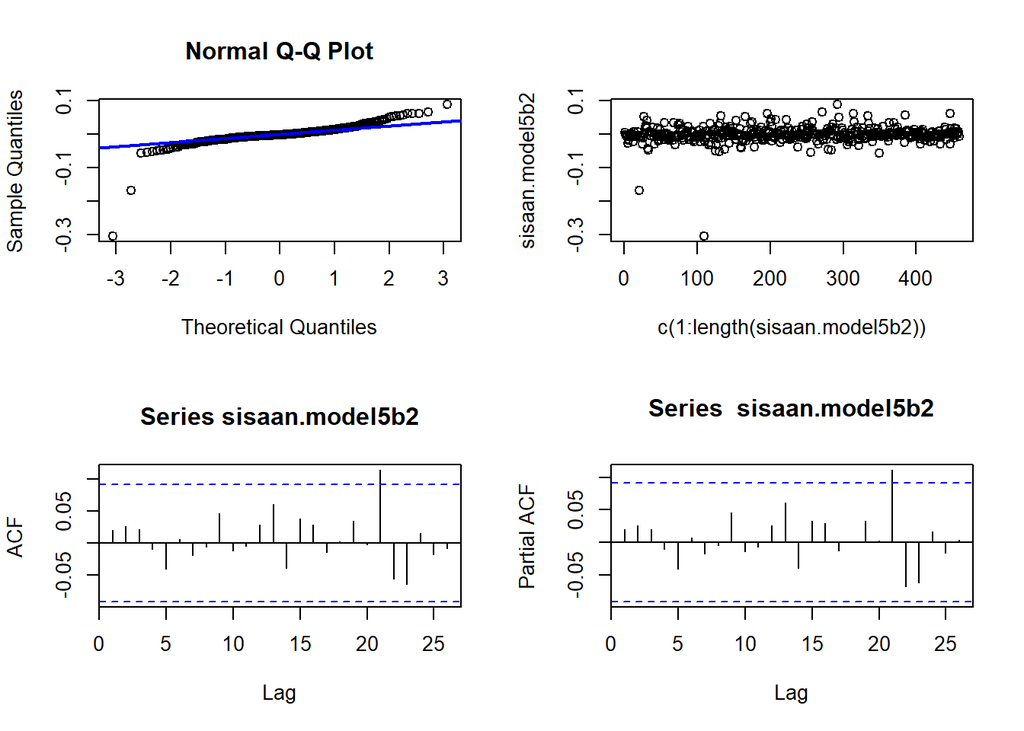

```r
#Eksplorasi
sisaan.model5b2 <- model5b2$residuals
par(mfrow=c(2,2))
qqnorm(sisaan.model5b2)
qqline(sisaan.model5b2, col = "blue", lwd = 2)
plot(c(1:length(sisaan.model5b2)),sisaan.model5b2)
acf(sisaan.model5b2)
pacf(sisaan.model5b2)
```

```r
par(mfrow = c(1,1))
```